# The Brighton Secondary School System - A Strategic View

A spatial interaction model of secondary school demand in Brighton & Hove, built entirely from published data — with the Longhill question and the 2028 boundary expansion

Author

Affiliation

Adam Dennett

Bartlett Centre for Advanced Spatial Analysis, University College London

Published

September 4, 2026

**NoteEverything here is built from published data**

No pupil-level records were used. Every input is published by a public body or reproducible from published sources using the code in this repository, and the build enforces that at runtime. Sources are listed in full in Section 27.

The model has parameters that only individual-level admissions data could pin down precisely. Rather than assume values for them, this analysis sweeps them across their full plausible range and reports how often each conclusion holds. Where a finding survives the whole range, no restricted data is needed to state it — and where one does not, that is reported too.

# 1 Executive summary

Brighton & Hove has signalled through recent admissions consultations that there is an impending crisis related to pupil numbers and school viability. School admission numbers, catchment boundaries, free school meal priority and the spatial distribution of school provision relative to pupil home locations are all factors that play into the strategic planning of provision in the city. This report models the city’s secondary system as a whole in order to ask what scenarios are more or less conducive to a well-functioning system of schools in the city. It is not clear that these scenarios are being discussed elsewhere in the council - they certainly are not being held in public forums.

## 1.1 The situation

**The Year 7 cohort is falling, and not evenly.** Surplus capacity has to appear somewhere, and the schools it appears at are not the ones with the most room to absorb it. Decisions taken in the next two admissions rounds will compound across fifteen to twenty years.

**The city already runs two admissions systems under one set of rules.** In the council’s own admissions guide, five schools carry the line *All preferences allocated unless offered a higher preference*. Three publish a breakdown by criterion, because for them the criteria decide something. **At the first group the admission criteria are inert**: catchment, siblings and the tiebreaker allocate nothing, because nobody is turned away.

## 1.2 What follows for the policies under discussion

**A catchment redraw cannot help an undersubscribed school by admitting more children, because it is not refusing any.** It can only work by changing which school families *name*. That is a slower and much weaker mechanism, and the evidence on the 2024 redraw does not obviously support it: families moved out of Longhill’s catchment appear to have gone on naming it, and families moved in were not obviously converted.

**Viability and social mix pull the same levers in opposite directions.** Every measure that would make an eastern school more viable — a redraw capturing more local families, a smaller admission number matched to local demand, retaining children who currently leave — works by binding the school more tightly to a deprived neighbourhood, and therefore concentrates disadvantage in its intake. Open allocation, the FSM criterion and the 2024 redraw all loosen that binding, spread disadvantage, and cost the eastern school. **A council can pursue a more socially mixed system, or strongly viable schools in its most deprived areas. The evidence does not show it can straightforwardly have both.**

**The City Child route around that trade-off was tested against public opinion and rejected.** That outcome is evidence, not an obstacle. The preference for a local school is not a Brighton peculiarity: distance decay of the strength found here appears in every spatial interaction model of school choice, in every kind of city, over seventy years. A policy premised on families not holding that preference is premised on something no evidence base supports.

**No single instrument is sufficient, and they behave very differently over time.** Reducing other schools’ admission numbers produces a gain to Longhill that is largest in the first year and fades as the cohort shrinks. Retaining children who currently leave the city is smaller at first and more durable. Moving the school and redrawing its catchment are worth little separately and considerably more together. **The instruments compose; none substitutes for the others, and the ones that look strongest in the first year are not the ones that still work in the tenth.** How large each is cannot be settled from published data, which is what recommendation 1 is about.

## 1.3 What is driving the sorting

**Families choose on headline attainment, not on what a school adds.** Demand tracks Attainment 8 at 0.94 and the intake-adjusted measure at 0.47. A headline score is very largely a description of the children who arrive rather than of what the school does with them — the intake-adjusted measure exists precisely to separate those two things, and it is the one families are not using. Choosing on the raw score means choosing a cohort and calling it a school.

**The council’s own guidance points them at it.** The admissions guide tells applicants to look at National Curriculum test results, public exam results and Ofsted. It nowhere mentions Progress 8, value added, or that results substantially reflect intake.

**Most disadvantaged children do not live in disadvantaged areas.** 27% of the city’s children live in the most deprived 30% of neighbourhoods; 24% of secondary pupils are FSM-eligible. Those cannot both describe the same children. An area-targeted intervention would miss roughly half the city’s disadvantaged pupils while reaching a majority in those areas who are not eligible.

**And the sorting happens mostly inside the geographic system, not between it and the faith sector.** The gap between the most and least representative non-religious schools is wider than the gap between the faith and non-faith sectors as wholes.

## 1.4 What the council should do

1. **Do not set Longhill’s admission number without calibrating this analysis on the council’s own records.** The question is not a fine judgement between adjacent options; it is whether the school supports three forms of entry or five, and published data cannot distinguish those. The work is a day’s analysis on records the admissions process already produces.
2. **Publish the evidence base.** Nine aggregate tables, none disclosive, most a single query, set out at Section 25.3. Publishing them alongside the allocation factsheets each March would let every party to these debates argue from the same evidence, and would cost a day of officer time a year.
3. **Publish an intake-adjusted attainment measure in the admissions guide**, alongside the raw one, with a sentence explaining what a headline grade mostly reflects. The guide already tables roll, preferences and admission numbers for every school. This is a column, not a new document, and it is the only lever identified anywhere in this report that acts on demand rather than shuffling supply.
4. **Stop treating catchment priority as an instrument where it is inert.** At five of the city’s schools it allocates nothing. Any proposal resting on a redraw should say explicitly whether it expects to work through priority, which it cannot at those schools, or through preference, which is slower, weaker and largely untested.
5. **State which goal is being pursued when the two conflict**, and be honest that pursuing it costs something measurable on the other. A consultation presenting a redraw as good for disadvantaged children *and* good for an eastern school is describing a trade-off as though it were a win.
6. **Model the whole system before changing one part of it.** Every result here says the decisions are not separable: reducing one school’s admission number pushes demand onto its neighbours and concentrates it, unevenly, on the school least able to absorb it. At present each change is consulted on separately, and nothing in that process would reveal whether they add up.

**NoteHow confident to be in each of these**

The findings above are not equally certain, and the report says so wherever they appear. Broadly: **the demographic arithmetic and the two-systems finding rest on the council’s own published documents and are not in doubt.** The choice findings rest on published attainment and preference data and are firm. **The figures for how large each policy effect would be are the least certain**, because the model’s key parameters cannot be estimated from published data, which is what recommendation 1 is about.

Where this report and a record-calibrated model would diverge, the open figures are almost always the more optimistic about Longhill.

# 2 What this is

Brighton & Hove has spent two years arguing about secondary school admissions. The council’s proposals, the objections to them, and the consultation evidence all rested on claims about what would happen if catchments moved, if a school shrank, or if children were reallocated. None were tested against a model of how families in the city actually choose schools.

This document builds that model from published data, and uses it to ask three questions:

1. **What are Brighton families responding to** when they choose a school?
2. **Can Longhill High School be sustained** at its current site and size — and does relocating it to the top of Elm Grove change that?
3. **What does the 2028 boundary expansion do**, when Brighton & Hove takes in East Saltdean, Telscombe and Peacehaven?

## 2.1 Where the data came from

Three tiers of material sit behind this report, and they are not equivalent.

**Published sources** carry everything in the main analysis: ONS population and small-area age structure, the council’s allocation factsheets and catchment maps, the Schools Adjudicator’s determination of 20 October 2025, DfE performance tables, and journey times routed over OSM and GTFS. All of it is reproducible from this repository.

**Evidence submitted to the Schools Adjudicator.** In determining the objections to the 2026/27 arrangements, the adjudicator required the council to produce a substantial evidence bundle — catchment boundaries, pupil forecasts, indices of deprivation, and preference and allocation counts by catchment area. As one of the objectors I received that bundle from the adjudicator in the ordinary course of the case. It was not published.

**It should have been.** Every table in it is aggregated to catchment or school level. None of it is disclosive: there is no individual, no address, and no cell small enough to identify a family. A short list of tables in the same spirit appears at Section 25.3. It is exactly the kind of material that lets residents, schools and researchers examine an admissions arrangement on the same evidence the authority uses — and there is no obvious reason it could not sit on the council’s website alongside the factsheets that already do. **A recurring theme of this report is that decisions are being argued out on incomplete public evidence; this bundle is a case where the evidence exists, is safe to release, and simply has not been.** Publishing it would cost nothing and would remove a good deal of the uncertainty flagged throughout these pages.

**Individual pupil records** are a different matter entirely, and are treated differently here. Where this document refers to what a calibrated model could produce, that modelling would rest on record-level data that we know the council holds, but that is not in the public domain. At points I may reference where the public data could be enhanced with a record-level model, and I would be happy to assist the council in running such a model should they want to work with me to do so — as an ONS accredited safe researcher, this is something I would be glad to help with while working to publish outputs in a non-disclosive way. **Nothing in this report is derived from record-level data.** No derived tables or fitted objects are included in this repository or its outputs.

## 2.2 Who wrote this, and why these methods

I am Professor of Urban Analytics at UCL’s Centre for Advanced Spatial Analysis. Spatial interaction models — the class of model this report is built on — have been a central part of my research for around fifteen years, and I have published on their formulation, calibration and application to population flows.

Three pieces are directly relevant to what is done here, and are offered so that the methods can be checked against the literature rather than taken on trust:

- Rowe, F., Lovelace, R. and **Dennett, A.** (2024) [Spatial interaction modelling: a manifesto](https://doi.org/10.4337/9781802203233.00019), in *A Research Agenda for Spatial Analysis*, Edward Elgar. Sets out the modern case for these models, including the reproducibility and open-code standards this report tries to meet.
- **Dennett, A.** and Wilson, A. (2013) [A multilevel spatial interaction modelling framework for estimating interregional migration in Europe](https://doi.org/10.1068/a45398), *Environment and Planning A*, 45(6). The multilevel treatment of nested flows, of which the catchment structure here is a simple case.
- **Dennett, A.** (2018) [Modelling population flows using spatial interaction models](https://discovery.ucl.ac.uk/id/eprint/10052338/), *Australian Population Studies*, 2(2). A practical account of calibrating and validating exactly the production-constrained form used in Section 3.

This matters for one reason. **The model in this report is not novel, and that is the point.** It is the standard production-constrained spatial interaction model, in continuous use since the 1960s, applied to school admissions in the way it is routinely applied to migration, retail catchments and hospital demand. Its behaviour is well understood, its failure modes are documented, and its calibration is textbook. Nothing here rests on a bespoke method that only its author can evaluate.

What *is* unusual is the constraint: building it entirely from published data, and being explicit at every point about what that costs. Where the published sources cannot support a conclusion, this report says so rather than reaching for one.

### 2.2.1 How this was built, and the part AI played

This analysis was produced in an extended working collaboration with Claude (Anthropic), and it is worth being straightforward about the division of labour, both because readers are entitled to know and because the collaboration is itself the subject of research.

**What the AI did.** Wrote and debugged the R that assembles the inputs, fits the models, designs the catchments and renders these documents; ran the routing over the OSM and GTFS networks; carried out the parameter sweeps; parsed the evidence bundles; built the tables and figures; and drafted much of the prose. It also caught several of its own errors on re-checking, and made some that had to be caught by me.

**What I did.** Set the questions, supplied the domain knowledge about Brighton’s schools and the policy history, chose the methods, judged what the results meant, and verified the output. Repeatedly, the substantive corrections came from knowing the city: that a catchment had been drawn wrongly, that a ward code was mismatched, that a figure was implausible for a place I know. The model is standard, but knowing whether an answer is *credible* is not something the analysis can do for itself.

**Why it matters that this is said.** The work is a contribution to [AI4CI](https://ai4ci.ac.uk/), a research programme examining how artificial intelligence can strengthen collective intelligence — the capacity of groups, institutions and communities to reason well together. This report is a reasonable specimen of what that looks like in practice. It covers ground I would not have covered alone: not because the reasoning was beyond me, but because the sheer volume of implementation — several thousand lines of code, dozens of model configurations, repeated rebuilds after each correction — would have consumed the time available many times over.

The direction of the assistance is worth noting. **It did not replace expertise; it removed the friction between having an idea and testing it.** Questions that would once have been shelved as too costly to answer — what if the catchments were redrawn optimally, what if every school shrank, what does the deprivation profile look like under nine different specifications — became cheap enough to just ask. Several of the findings here exist only because a question that would previously have cost a fortnight cost twenty minutes.

That cuts both ways, and the failure mode is real: it is now equally cheap to produce confident, well-formatted analysis that is wrong. Most of the errors corrected during this work were caught because a result contradicted something I knew about the city, not because anything in the pipeline flagged it. **The expert judgement is not an optional layer on top of the automation; it is the part that makes the automation safe to use.** An analysis of this kind produced without someone who knows the subject would be faster, longer, and considerably more dangerous.

**ImportantAn offer to the council, and why it matters now**

**This analysis is offered as the beginning of a collaboration, not as a criticism.**

Brighton & Hove faces a demographic change that will run for the next fifteen to twenty years. The Year 7 cohort is falling, four wards join the authority in 2028, and the schools affected are not the ones with the most capacity to absorb it. Decisions taken in the next two admissions rounds — one school’s admission number here, one catchment boundary there — will compound across that whole period.

The difficulty is that those decisions are currently being taken **one at a time**, each on its own evidence, and often in response to whichever case has been argued most forcefully. A change to Longhill’s admission number is considered separately from a change to Dorothy Stringer’s, which is considered separately from where a catchment boundary runs, which is considered separately from what happens when Peacehaven joins. Each may be defensible alone. Together they may not add up to a system that works, and nothing in the current process would reveal that.

This document exists to make a different kind of conversation possible: one in which the city’s schools are treated as a **single interacting system**, where a change at one school is understood in terms of what it does to every other, across the whole period the demographic change is going to last.

It is built entirely from published data, deliberately, so that anyone can check it. But published data has hard limits, and this report is explicit about every one of them.

**Two kinds of flag appear throughout, and they mean different things:**

- **“This section cannot be done on published data”** — the analysis is absent entirely. Five sections are placeholders of this kind, saying what the records would establish.
- **“This result is likely to differ from the calibrated model”** — the analysis *is* here, but the open version and the record-calibrated version disagree. These flags say **which direction the open figure is wrong in, and by roughly how much**, so a reader can discount appropriately rather than take the number at face value.

The second kind matters most. Where this report and the calibrated model diverge, **the open model is almost always the more optimistic of the two about Longhill** — and the flags say so at each point rather than only in a methods appendix.

Those comparison figures are quoted precisely, because a warning that a number is wrong is useless without saying by how much. They come from modelling carried out on data held under separate arrangements, and are given here as reference points rather than as results this document establishes. Nothing in them can be reproduced from this repository; everything else here can.

**What is being asked for is access to the admissions records the council already holds** — preferences, offers, allocation criteria, home postcodes — under the arrangements that already govern research use of pupil data. Nothing new would need collecting. In return, the analysis becomes far sharper: the sections marked below stop being gaps, the largest source of error in this report disappears, and the council gets a tested model of its own system that can be re-run against any proposal before it is consulted on.

The alternative is not that these questions go unanswered. It is that they get answered by whoever argues loudest, using whatever numbers are to hand.

**ImportantDistance decay is not an assumption of this model. It is the most reliably observed regularity in human geography.**

Everything in this report rests on one empirical fact, so it is worth stating before the method rather than after it.

**People interact less with things that are further away, and the fall-off is steep, regular, and measurable.** It has been observed in migration between regions and between countries; in commuting; in retail catchments; in access to hospitals and GP surgeries; in telephone calls, freight, trade and marriage partners; and in school choice, repeatedly, in every kind of city and every national system where anyone has looked. It has been formalised since the 1940s and modelled continuously since the 1960s. It is among the closest things the social sciences have to a law.

This matters because policy is sometimes designed as though it were not true — as though where a school sits were an administrative detail, and families could be redistributed across a city if the arrangement asked them to. **That view has a long record of being tested and a short record of surviving.** It is not that Brighton’s families are unusually attached to their neighbourhoods, or unusually resistant to being moved. It is that no population anywhere behaves the way such a policy needs them to.

The model here does not assume distance decay in order to reach a conclusion. It **measures** it, from Brighton’s own admissions data, and finds a value squarely in the range the literature reports elsewhere. A reader who wants to reject the conclusions of this report has to reject that measurement, and with it seventy years of consistent evidence from every domain in which human beings choose where to go.

Nothing here says distance is the *only* thing that matters — attractiveness, attainment, reputation, faith and siblings all enter the model, and Section 5 is devoted to separating geography from everything else. The claim is narrower and firmer: **any account of school demand that leaves distance out will be wrong, and any policy premised on families ignoring it will fail.**

# 3 Method

## 3.1 The model

A production-constrained spatial interaction model:

$$T_{ij} = A_i O_i W_j^{\alpha} c_{ij}^{-\beta} \qquad
A_i = \frac{1}{\sum_j W_j^{\alpha} c_{ij}^{-\beta}}$$

where $T_{ij}$ is the flow of children from neighbourhood $i$ to school $j$, $O_i$ the children living in $i$, $W_j$ school $j$’s attractiveness, $c_{ij}$ the walk/bus journey time, and $A_i$ the balancing factor that places every child somewhere. Modelled flows are then constrained to school capacity by iterative proportional fitting, so demand displaced from a full school cascades to the next-best option rather than vanishing.

**NoteWhy this model has a catchment term and the calibrated one does not**

The model here carries an explicit **catchment priority parameter**, $\gamma$, which adds a fixed bonus to a school’s utility for families living in its catchment. It is swept from 0 to 2.4 because published data cannot pin it down.

The calibrated model has no such term. It does not need one, and that is worth understanding rather than passing over. With individual records you can fit a **destination fixed effect** for every school — a single number absorbing everything that makes a school more or less chosen, whatever the cause: reputation, buildings, sixth form, siblings, catchment, or whatever else is operating. The catchment effect is then not assumed at all. It is measured, by comparing what happens to families inside and outside a catchment who named the same school.

So $\gamma$ here is a **stand-in for a measurement**, not a rival theory of how admissions work. That has two consequences worth carrying through the rest of this document. It is why catchment priority appears as a swept band rather than a number. And it is why the sweep can be misleading: a single $\gamma$ applied city-wide forces catchment priority to be worth the same at every school, when the evidence in Section 9 suggests it is worth a great deal at an oversubscribed school and close to nothing at an undersubscribed one. The variance decomposition in Section 23 shows $\gamma$ accounting for under 3% of the variation in the answer, which is reassuring — but that is partly because a parameter forced to be uniform cannot express the effect that actually matters.

**A note on notation.** $c_{ij}$ is the generalised *cost* of travel from $i$ to $j$, measured in minutes of walk and bus journey time routed over the real network — not a straight-line distance. The symbol is held to that meaning throughout. The one place a true distance appears is the competing-destinations term in Section 5, where $d_{jk}$ is the straight-line separation between two *schools* in kilometres; that is a different quantity and keeps a different symbol.

Method after Dennett, *Idiots’ Guide to Spatial Interaction Modelling*, [Part 1](https://rpubs.com/adam_dennett/257231) and [Part 2](https://rpubs.com/adam_dennett/259068), and the references in Section 2.2.

## 3.2 How $W_j$ was arrived at

$W_j$ — how attractive families find each school, net of how far away it is — is the hardest term in the model to pin down, and the one this bundle can say least about. It is worth being explicit about that before any result rests on it.

**The problem.** Attractiveness cannot be read off a school characteristic, because every candidate is entangled with location. A school with high Attainment 8 may be sought-after because it teaches well, or because it sits where affluent families already live. Put a location-correlated variable into a model that also contains distance and the two fight over the same variation.

**Why this version cannot estimate it.** Resolving that needs individual preference records — who named which school, from where. With those, $W_j$ can be estimated freely for each school as a destination fixed effect, letting the data say how much more often a school is named than its location alone would predict. Published statistics give only the margins of that table: how many children live in each area, how many places each school filled. They do not give the interactions, which is the identification problem set out in Section 23.

**So it is swept, not chosen.** Four specifications are carried through every calculation, spanning the plausible range from “nothing distinguishes schools” to “demand tracks results”:

```r
inp$attract %>%
  transmute(School = name,
            `Equal` = 1,
            `By PAN` = round(W_pan, 2),
            `By first preferences` = round(W_prefs, 2),
            `By Attainment 8` = round(W_att8, 2)) %>%
  arrange(desc(`By first preferences`)) %>%
  tbl(caption = "The four attractiveness specifications. Each is scaled so the city average is 1.")
```

The four attractiveness specifications. Each is scaled so the city average is 1.

| School | Equal | By PAN | By first preferences | By Attainment 8 |
| --- | --- | --- | --- | --- |
| King's School | 1 | 0.66 | 1.68 | 2.43 |
| Varndean School | 1 | 1.20 | 1.55 | 1.78 |
| Cardinal Newman Catholic School | 1 | 1.45 | 1.42 | 1.72 |
| Dorothy Stringer School | 1 | 1.32 | 1.07 | 1.77 |
| Blatchington Mill School | 1 | 1.32 | 1.07 | 1.40 |
| Patcham High School | 1 | 0.90 | 1.02 | 1.04 |
| Portslade Aldridge Community Academy | 1 | 0.88 | 0.85 | 0.87 |
| Hove Park School | 1 | 0.72 | 0.75 | 0.82 |
| Brighton Aldridge Community Academy | 1 | 0.72 | 0.65 | 0.37 |
| Longhill High School | 1 | 1.08 | 0.47 | 0.39 |
| Peacehaven Community School | 1 | 0.72 | 0.47 | 0.51 |

- **Equal** — every school identical. Nobody believes it, but it bounds the space and is what Section 5 runs on.
- **Proportional to PAN** — bigger schools attract more, a pure size effect with no quality content.
- **Published first preferences** — the council’s own factsheets, averaged over seven recent rounds. The closest open proxy for revealed demand, and the central specification used where a single one is needed.
- **Attainment 8** — demand tracks published results.

**ImportantThis is the largest single unknown in the open model**

The variance decomposition in Section 23 attributes **44%** of the variation in the answer to which attractiveness specification is used — more than distance decay (6%) and catchment strength (3%) combined, several times over.

That is worth stating plainly because it identifies what restricted data would actually be worth having. Precise travel-time behaviour is **not** the gap — $\beta$ barely matters. **School-level revealed preference is.** An origin–destination matrix of Year 7 preferences by area and destination school, which carries no disclosure risk at catchment level, would replace the widest band of uncertainty in this document with a measurement.

Two consequences follow for how to read what comes next. Conclusions that hold across all four specifications are safe to state without restricted data — and those are reported as such. Conclusions that depend on which specification is chosen are flagged, and the size of the dependence is given rather than hidden.

Note that first preferences bundle a school’s reputation together with where it happens to be: a school in the middle of the city collects preferences partly because it is convenient. That is exactly the entanglement the sweep exists to handle, and it is why the “equal” and “by PAN” specifications are kept in the range rather than discarded as implausible.

## 3.3 Where the journey times come from

Every journey time here is routed by `r5r` over an OpenStreetMap street network and a GTFS bus timetable, rather than measured as straight-line distance. Those two inputs do a great deal of the work, so they are worth showing - not as an undifferentiated tangle of every service pattern in the city, but as the journeys themselves, leg by leg.

```r
nm <- readRDS(file.path(PUBLIC_OUT, "network_maps.rds"))
rg_path <- file.path(PUBLIC_OUT, "route_geometries.rds")
rg <- if (file.exists(rg_path)) readRDS(rg_path) else NULL

m <- leaflet() %>% addProviderTiles(providers$CartoDB.Positron) %>%
  addPolylines(data = nm$routes, color = "#999999", weight = 1, opacity = 0.25,
               group = "Whole bus network")

if (!is.null(rg)) {
  wk <- rg$legs %>% filter(leg_mode == "WALK")
  bs <- rg$legs %>% filter(leg_mode != "WALK")
  m <- m %>%
    addPolylines(data = bs, color = "#2C6E9B", weight = 5, opacity = 0.85,
                 label = ~paste0(journey, " — bus ", route, ", ",
                                 round(minutes), " min"),
                 group = "Worked journeys") %>%
    addPolylines(data = wk, color = "#d95f02", weight = 4, opacity = 0.9,
                 dashArray = "4,6",
                 label = ~paste0(journey, " — walk, ", round(minutes), " min"),
                 group = "Worked journeys")
}

m %>%
  addCircleMarkers(data = nm$stops, radius = 1.5, color = "#2C6E9B",
                   stroke = FALSE, fillOpacity = 0.5,
                   label = ~stop_name, group = "Bus stops") %>%
  addCircleMarkers(data = st_transform(
                     st_as_sf(inp$schools, coords = c("easting", "northing"),
                              crs = 27700), 4326),
                   radius = 5, color = "black", weight = 1,
                   fillColor = "#d95f02", fillOpacity = 0.9,
                   label = ~name, group = "Schools") %>%
  addLayersControl(overlayGroups = c("Worked journeys", "Whole bus network",
                                     "Bus stops", "Schools"),
                   options = layersControlOptions(collapsed = FALSE)) %>%
  hideGroup(c("Bus stops", "Whole bus network"))
```

[interactive chart not shown]

Seven worked journeys, routed leg by leg. Orange is walking and follows the street network; blue is a bus leg and follows the service pattern. Toggle the full bus network on for context. Hover a leg for its mode, service and duration.

```r
if (!is.null(rg)) {
  rg$summary %>%
    transmute(Journey = journey, `Minutes` = total_minutes,
              Legs = legs, `Bus services` = services) %>%
    tbl(caption = "The same journeys as numbers. Each is routed door to door on a full-timetable weekday morning.")
}
```

The same journeys as numbers. Each is routed door to door on a full-timetable weekday morning.

| Journey | Minutes | Legs | Bus services |
| --- | --- | --- | --- |
| Hove to Dorothy Stringer | 43 | 3 | 5B |
| Kemptown to Longhill | 25 | 5 | 12, 2 |
| Peacehaven to Longhill | 39 | 5 | 14, 2 |
| Saltdean to Longhill | 19 | 5 | 12A, 2 |
| Whitehawk to Dorothy Stringer | 52 | 5 | 21, 5B |
| Whitehawk to Longhill | 44 | 3 | 2 |
| Woodingdean to Longhill | 11 | 3 | 2 |

The feed carries **2,172 stops on 84 routes**, and the network was built from a merged East and West Sussex OpenStreetMap extract covering BN1, BN2, BN3, BN41, BN42, BN45, BN10, BN9, BN25, BN7 — 7,896 origin postcodes in all.

### 3.3.1 What the network implies for the two sites

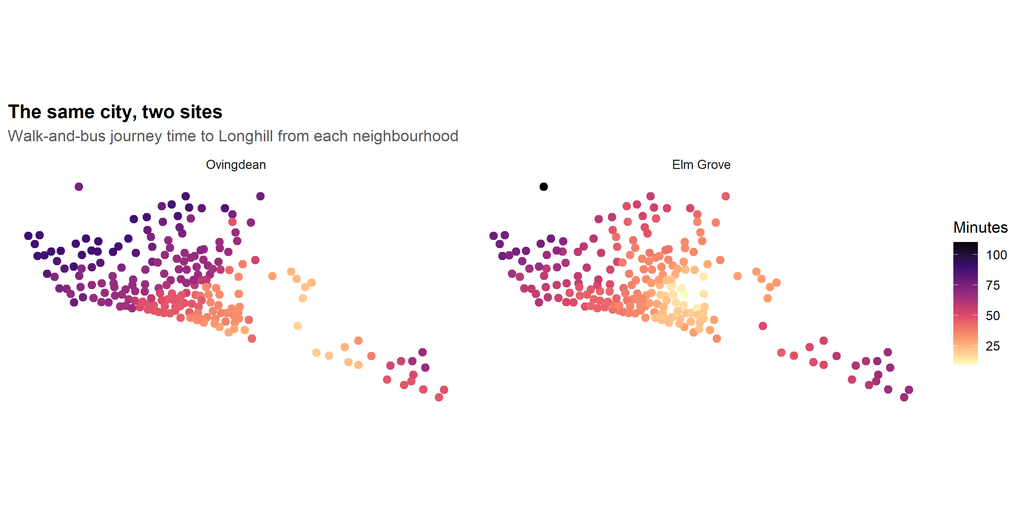

Journey time to Longhill from every neighbourhood, at its current site and at the Elm Grove site. Darker is longer.

```r
nm$surface %>%
  st_drop_geometry() %>%
  select(zone_e, zone_n, Ovingdean = ovingdean, `Elm Grove` = elm_grove) %>%
  pivot_longer(c(Ovingdean, `Elm Grove`), names_to = "site", values_to = "mins") %>%
  mutate(site = factor(site, c("Ovingdean", "Elm Grove"))) %>%
  ggplot(aes(zone_e, zone_n, colour = mins)) +
  geom_point(size = 2.4) +
  facet_wrap(~ site) +
  scale_colour_viridis_c(option = "magma", direction = -1, name = "Minutes") +
  coord_equal() +
  labs(title = "The same city, two sites",
       subtitle = "Walk-and-bus journey time to Longhill from each neighbourhood",
       x = NULL, y = NULL) +
  theme(axis.text = element_blank(), panel.grid = element_blank())
```

The median neighbourhood is **65 minutes** from the current site and **39 minutes** from Elm Grove. Relocation saves a median of 17 minutes, and costs time in 13% of neighbourhoods — those in the far south-east, which is the trade discussed later.

### 3.3.2 Worked journeys

Model outputs are easier to trust when a few of them can be checked against local knowledge. These are real postcodes, routed by the same network that produces every other number here.

```r
nm$journeys %>%
  transmute(From = place, Postcode = pcd,
            Longhill = round(longhill), `Elm Grove site` = round(elm_grove),
            Stringer = round(ds), Varndean = round(varndean),
            `Cardinal Newman` = round(cardinal_n),
            `Lewes Priory` = round(priory_lewes)) %>%
  tbl(caption = "Walk-and-bus journey time in minutes, morning peak")
```

Walk-and-bus journey time in minutes, morning peak

| From | Postcode | Longhill | Elm Grove site | Stringer | Varndean | Cardinal Newman | Lewes Priory |
| --- | --- | --- | --- | --- | --- | --- | --- |
| Whitehawk (Whitehawk Rd) | BN2 5FL | 34 | 18 | 52 | 45 | 64 | 71 |
| Woodingdean (centre) | BN2 6PA | 22 | 30 | 52 | 45 | 64 | 71 |
| Kemptown (St George's Rd) | BN2 1ED | 36 | 22 | 38 | 32 | 34 | 71 |
| Rottingdean (High St) | BN2 7HE | 21 | 44 | 62 | 54 | 49 | 82 |
| Saltdean (Longridge Ave) | BN2 8LF | 21 | 50 | 62 | 54 | 49 | 82 |
| Hove (Church Rd) | BN3 2FL | 47 | 44 | 52 | 45 | 25 | 71 |
| Peacehaven (Roderick Ave) | BN10 8AY | 68 | 66 | 90 | 87 | 83 | 112 |

## 3.4 Why this analysis sweeps rather than calibrates

Published statistics give the *margins* of the origin-destination table — how many children live in each area, how many places each school fills — but not the flows between them. Without interaction data, $\beta$ is not identified.

So instead of asserting a value, the analysis runs the model across the whole plausible range of the three parameters that matter, and reports how often each conclusion holds:

| Parameter | Swept over | Controls |
| --- | --- | --- |
| $\beta$ | 1.5 – 3.2 | how sharply demand falls with journey time |
| $W_j$ | 4 specifications | school attractiveness net of location |
| $\gamma$ | 0 – 2.4 | strength of catchment priority |

# 4 The system as it stands

```r
catch_sf  <- read_catchments("optionZ") %>% st_transform(4326)
catch_pre <- read_catchments("pre2024") %>% st_transform(4326)

sch_sf <- inp$schools %>%
  left_join(os$choice %>% select(urn, first_pref, prefs_per_place, att8, va), by = "urn") %>%
  st_as_sf(coords = c("easting", "northing"), crs = 27700, remove = FALSE) %>%
  st_transform(4326)

zone_sf <- inp$zones %>%
  st_as_sf(coords = c("zone_e", "zone_n"), crs = 27700) %>% st_transform(4326)

pal_c <- colorFactor(unname(cat_cols[catch_sf$catchment]), domain = catch_sf$catchment)

leaflet() %>%
  addProviderTiles(providers$CartoDB.Positron) %>%
  addPolygons(data = catch_sf, fillColor = ~pal_c(catchment), fillOpacity = 0.12,
              color = "grey40", weight = 1.5, label = ~catchment,
              group = "Catchments (option Z, from 2026)") %>%
  addPolygons(data = catch_pre, fill = FALSE, color = "black", weight = 1.5,
              dashArray = "5,5", label = ~paste0(catchment, " (pre-2024)"),
              group = "Catchments (pre-2024)") %>%
  addCircleMarkers(data = zone_sf, radius = ~sqrt(Oi) * 1.6, color = "grey30",
                   weight = 0, fillOpacity = 0.35,
                   label = ~paste0(zone, " — ", round(Oi), " children"),
                   group = "Where the children are") %>%
  addCircleMarkers(data = sch_sf, radius = ~sqrt(pan2024) / 1.1, color = "black",
                   weight = 1, fillColor = "#d95f02", fillOpacity = 0.85,
                   label = ~name,
                   popup = ~paste0("<b>", name, "</b><br>PAN 2024: ", pan2024,
                                   "<br>First preferences: ", first_pref,
                                   "<br>Attainment 8: ", round(att8, 1)),
                   group = "Schools") %>%
  addLayersControl(
    overlayGroups = c("Catchments (option Z, from 2026)",
                      "Catchments (pre-2024)",
                      "Where the children are", "Schools"),
    options = layersControlOptions(collapsed = FALSE)) %>%
  hideGroup("Catchments (pre-2024)")
```

[interactive chart not shown]

Brighton & Hove secondary schools and Year 7 demand. Filled areas are the option Z catchments in force from 2026 entry; the dashed outline is the map they replaced. Circles are schools sized by admission number; grey dots are neighbourhoods sized by their modelled 2026 cohort.

The map shows the city’s structural problem. The children are concentrated in the centre and west; two of the eleven schools — Longhill in the far south-east, and to a lesser extent BACA in the north-east — sit away from where families live.

**NoteWhich catchment map this uses**

The city consulted on secondary catchments in 2024 and determined a new scheme in March 2025. Under the School Admissions Code an arrangement determined in February or March of one year first applies to entry the following September, so the new map — “option Z” — governs entry from 2026. The filled areas above are option Z; switch on the dashed layer to see the boundaries it replaced.

The change is confined to east Brighton, and it is not cosmetic. It moves Kemptown into the Longhill catchment and part of Whitehawk & Marina out of it into Stringer and Varndean: 24 of this model’s 209 origin zones change catchment, about 8% of the city’s live postcodes.

Because that boundary runs *through* LSOAs, this analysis assigns catchment to individual postcodes and then splits each LSOA accordingly, rather than allocating whole LSOAs by their centroid. Assigning wholesale would register only a fraction of the children the redraw actually moves. Origin zones here are therefore LSOA × catchment, and each is split on **both** maps at once so the two regimes sit on identical geography and can be compared directly.

# 5 Brightopia: what the map alone would do

Before any modelling that requires assumptions, there is a question that requires none.

Imagine a Brighton in which every secondary school is identical — same size, same buildings, same staff, same inspection grade, no religious character — and every child is identical too. The only thing separating the ten schools is where they stand, and they stand exactly where they stand today. Which school would each child attend if the only thing that could distinguish them was how long it takes to get there?

This is the “Brightopia” model from the earlier [schools_wk3](https://adamdennett.github.io/BH_Schools_2/schools_wk3.html) work, re-run on the rebuilt routed travel matrix. It is the most robust thing in this document, because it uses no attainment data, no Ofsted grade, no preference counts, no catchment rule and no faith criterion. Strip all of that out and what remains is the geography of the city.

**WarningModelled intake is a market share, not a measure of location**

In a production-constrained model the modelled intake of school $j$ is

$$T_j = \sum_i O_i \frac{f(c_{ij})}{\sum_k f(c_{ik})}$$

Reading that in words: $T_j$ is the number of children school $j$ ends up with. $i$ is a neighbourhood and $O_i$ the children living in it. The top of the fraction, $f(c_{ij})$, is how attractive the journey from that neighbourhood to school $j$ is — bigger when the journey is shorter.

**The** $k$ on the bottom is the important one. It is a counter that runs over *every school in the city, one after another*, adding up the same journey-attractiveness term for each. So $\sum_k f(c_{ik})$ means “how easy it is to get from this neighbourhood to schools in general” — not to school $j$, but to all of them together, $j$ included.

Dividing one by the other turns an absolute quantity into a **share**. The fraction asks: of all the school-reaching convenience available to this neighbourhood, what proportion belongs to school $j$? That proportion can fall in two entirely different ways — because the top gets smaller, meaning school $j$ is genuinely hard to reach, or because the bottom gets bigger, meaning the neighbourhood has plenty of other schools within easy reach. An earlier version of this section reported the result as a single “site index”, which treated the second as though it were the first.

Dorothy Stringer exposes the problem. It sits in the middle of the city with Varndean 470 metres away and Cardinal Newman and Hove Park close behind. Its Brightopia intake is low not because children cannot reach it, but because everyone who can reach it can also reach several alternatives.

The two are separated below: **potential (Hansen) accessibility**, the distance-weighted count of children within reach, and **Fotheringham’s competing-destinations term**, the accessibility of each school to the other schools.

```r
bright$at_original_beta %>%
  transmute(School = name, PAN = pan2024,
            `Children reachable` = round(access_index),
            `Rivals nearby` = round(compete_index),
            `Brightopia intake` = round(100 * share_index),
            `Mean journey (min)` = round(mean_travel, 1)) %>%
  arrange(`Children reachable`) %>%
  tbl(caption = paste0(
    "Accessibility and competition, separated, at beta = ", bright$beta_original,
    ". Both indices are set to 100 at the city average."))
```

Accessibility and competition, separated, at beta = 1.5. Both indices are set to 100 at the city average.

| School | PAN | Children reachable | Rivals nearby | Brightopia intake | Mean journey (min) |
| --- | --- | --- | --- | --- | --- |
| Longhill High School | 270 | 71 | 36 | 88 | 43.5 |
| Brighton Aldridge Community Academy | 180 | 81 | 54 | 89 | 44.0 |
| King's School | 165 | 84 | 93 | 82 | 46.0 |
| Dorothy Stringer School | 330 | 91 | 146 | 90 | 43.4 |
| Patcham High School | 225 | 102 | 92 | 97 | 40.4 |
| Blatchington Mill School | 330 | 110 | 143 | 104 | 39.0 |
| Hove Park School | 180 | 111 | 139 | 107 | 38.5 |
| Portslade Aldridge Community Academy | 220 | 111 | 55 | 109 | 36.6 |
| Varndean School | 300 | 111 | 141 | 109 | 38.0 |
| Cardinal Newman Catholic School | 360 | 129 | 100 | 125 | 34.8 |

**NoteHow the two columns are calculated**

**Children reachable** is potential accessibility, the standard Hansen measure. For school $j$ it adds up every neighbourhood’s children, each discounted by how long the journey takes:

$$A_j = \sum_i O_i \, c_{ij}^{-\beta}$$

$i$ runs over neighbourhoods, $O_i$ is the children living in one, $c_{ij}$ the journey time to school $j$, and $\beta$ the distance decay. A child ten minutes away counts for far more than one an hour away. Nothing about other schools enters this — it is purely “how many children can get here easily”.

**Rivals nearby** is Fotheringham’s competing-destinations term. Same shape, but the sum runs over *schools* rather than neighbourhoods:

$$C_j = \sum_{k \neq j} W_k \, d_{jk}^{-\sigma}$$

Here $k$ counts through the other schools — the $k \neq j$ underneath the sum means “every school except this one” — $d_{jk}$ is the distance from school $j$ to school $k$, $W_k$ that school’s weight, and $\sigma$ how fast the effect fades with distance. The change of symbol is deliberate: $d_{jk}$ is a straight-line distance in kilometres between two schools, not a travel-time cost like $c_{ij}$. Nobody makes the journey from one school to another, so routing it would be meaningless — what matters is only how clustered the schools are. In Brightopia every school is identical, so $W_k$ drops out and the measure becomes pure spatial clustering: with $\sigma = 1$ it reduces to adding up one-over-the-distance to each of the other nine schools.

Worked through for the two schools that matter here:

[output not shown]

Stringer’s total is four times Longhill’s, and Varndean alone — 470 metres away — supplies more competition to Stringer than *all nine* of Longhill’s rivals put together. Setting the city average to 100 gives the index values in the table above.

The two correlate at only 0.59, and the schools at the bottom of the intake column get there by opposite routes.

**Longhill has the lowest potential accessibility in the city**, at 71, together with the **lowest** competition term at 36. It has almost no rivals nearby, so its low intake cannot be crowding — fewer children can simply reach it.

**Dorothy Stringer is the opposite**: accessibility 91, but the **highest** competition term in the city at 146. Its low modelled intake is crowding, and crowding is exactly what a school overcomes by being wanted — which Stringer is, filling to its admission number every year. Longhill cannot escape its position the same way, because no amount of popularity conjures children into the south-east corner of the city.

Measuring each school against its **own** admission number would mislead in a further way, because the city has 2,560 places for about 2,267 children — every school is below its PAN by construction, and the largest look worst. That is why both indices above are set to 100 at the city average.

**NoteA caution about Dorothy Stringer’s journey times**

Stringer and Varndean are 470 metres apart, yet the routed matrix makes Stringer slower from most of the city — by a median of about five and a half minutes. That may be a real difference in bus access, or an artefact of where `r5r` snapped each school onto the network; it has not been established which.

It is large enough to matter. Giving Stringer exactly Varndean’s journey times raises its Brightopia intake index by roughly 14 points while moving every other school by no more than three. So a good part of Stringer’s apparent disadvantage is this single discrepancy rather than either location or competition. Longhill’s position is untouched by it, because the anomaly is between two central schools.

### 5.0.1 Would a competing-destinations model fit better?

The separation above is descriptive. Fotheringham’s competing-destinations model (*A new set of spatial-interaction models: the theory of competing destinations*, Environment and Planning A, 1983) goes further, arguing that the unadorned gravity model is misspecified when destinations cluster: families process the choice hierarchically, picking an area and then a school within it, so omitting a competition term loads spatial structure onto the distance parameter and biases it.

$$T_{ij} = A_i O_i W_j^{\alpha} C_j^{\delta} c_{ij}^{-\beta}$$

Fitting $\delta$ requires observed origin–destination flows, which is exactly what published statistics do not provide — the identification problem set out in Section 3. So this bundle can construct $C_j$, as it does above, but cannot estimate its coefficient.

There are good reasons to expect $\delta$ to come out close to zero here, and they are worth setting out because they are structural rather than empirical.

A production-constrained model with origin fixed effects already handles competition twice over: the balancing factor $A_i$ normalises each origin’s flows across all destinations, so a school’s accessibility relative to its rivals is partly absorbed before any explicit competition term is added. Competing-destinations corrections were developed for large interaction systems — inter-city migration, regional retail hierarchies — where destinations vary enormously in how clustered they are. **Ten schools inside nine miles offer very little of that variation to work with.** In a system this compact, $C_j$ is close to collinear with the accessibility already captured, and a coefficient on it has little left to explain.

**That is an expectation, not a result.** Confirming it needs individual preference records, for the identification reason above, and this analysis has not been able to test it. If $\delta$ turned out to be materially different from zero, the distance parameter reported here would be biased and the Brightopia figures would need revisiting. It is one of the assumptions most worth checking if the records become available, and it is listed at Section 25.3 for that reason.

The descriptive separation above does not depend on it either way.

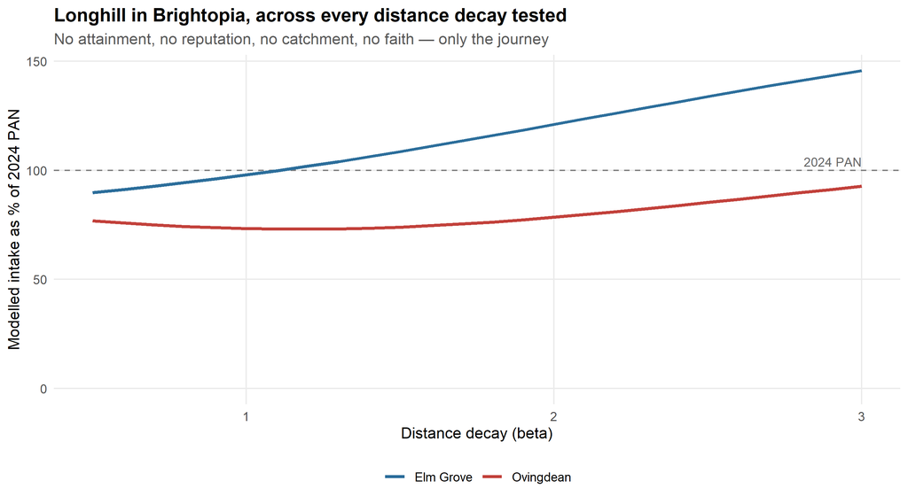

Longhill in Brightopia, at every distance decay tested. Nothing here depends on how good any school is thought to be.

```r
bright$lh_sweep %>%
  select(beta, Ovingdean = fill_now, `Elm Grove` = fill_elm) %>%
  pivot_longer(-beta, names_to = "site", values_to = "fill") %>%
  ggplot(aes(beta, 100 * fill, colour = site)) +
  geom_hline(yintercept = 100, linetype = "dashed", colour = "grey50") +
  geom_line(linewidth = 1.1) +
  annotate("text", x = max(bright$lh_sweep$beta), y = 104, label = "2024 PAN",
           hjust = 1, size = 3.2, colour = "grey40") +
  scale_colour_manual(values = c(Ovingdean = "#C2413B", `Elm Grove` = "#2C6E9B")) +
  expand_limits(y = 0) +
  labs(title = "Longhill in Brightopia, across every distance decay tested",
       subtitle = "No attainment, no reputation, no catchment, no faith — only the journey",
       x = "Distance decay (beta)", y = "Modelled intake as % of 2024 PAN",
       colour = NULL) +
  theme(legend.position = "bottom")
```

At the decay value the original used, Brightopia gives Longhill 200 children where it stands and 293 at the top of Elm Grove. It sits below its 2024 admission number across 100% of the decay range at Ovingdean and 27% at Elm Grove, and relocation raises its distance-only intake at **every** value of beta tested. There is no plausible decay parameter at which the current site is the better placed of the two.

This is worth separating from everything that follows. The rest of this document depends on assumptions about attractiveness and admissions priority that open data cannot pin down. This section does not. Whatever else is uncertain, Longhill is poorly sited relative to where Brighton’s children live, and the Elm Grove site is not.

# 6 Calibration

**NoteThis section cannot be done on published data**

A spatial interaction model has two parameters that decide everything it says: **how sharply distance deters** a family from choosing a school ($\beta$), and **how much being in catchment shifts a choice** ($\gamma$). Both are estimated by fitting the model to observed flows — how many children actually travel from each neighbourhood to each school.

Published data gives school totals, not flows. There is no open way to estimate either parameter, so this document does not try. Instead it **sweeps** both across their full plausible range and reports which conclusions hold everywhere in that range and which depend on where in it the truth lies (Section 23). That is an honest response to the limitation, and it is why several findings here are stated as ranges rather than numbers.

**With admissions records this becomes a half-day’s work.** A Poisson regression of flows on log distance and a catchment indicator, with origin fixed effects, returns both parameters with standard errors. There is good reason to expect the distance decay to come out stable across specifications and years. If it does, the wide bands in this report are not irreducible uncertainty about Brighton at all — only uncertainty about what the records would say.

The gain is not academic. Every figure in this report that carries a range would carry a number instead.

# 7 What are families actually choosing?

Before modelling anything, a question that can be answered from published data alone: does demand for a school track its **headline attainment**, or the **value it adds** to the pupils it teaches?

**NoteThe council’s own guidance points families at one of these two measures**

This is not only a question about how families happen to behave. The council’s *Secondary school admissions guide 2026–2027* tells applicants what to look at, and the performance signals it names — National Curriculum test results, public exam results, Ofsted — are all measures of raw attainment. It nowhere mentions value added, Progress 8, or the fact that a school’s results substantially describe the children who sit them.

So whatever this section finds about how families choose, the authority is actively directing them towards one of the two measures. That is examined in full at Section 21.1.2, once the evidence on which measure predicts demand is on the table.

Both are published. Attainment 8 appears in the DfE performance tables. Value-added — how a school’s results compare with what its intake would predict — comes from the contextual models in school_attainment_tool. Demand comes from the council’s own allocation factsheets.

```r
os$choice %>%
  transmute(School = school, PAN = pan, `First preferences` = first_pref,
            `Prefs per place` = round(prefs_per_place, 2),
            `Attainment 8` = round(att8, 1),
            `Value-added` = round(va, 2)) %>%
  arrange(desc(`Prefs per place`)) %>%
  tbl(caption = "Published demand and published performance")
```

Published demand and published performance

| School | PAN | First preferences | Prefs per place | Attainment 8 | Value-added |
| --- | --- | --- | --- | --- | --- |
| Varndean School | 300 | 456 | 1.52 | 53.5 | 3.42 |
| King's School | 165 | 242 | 1.47 | 56.9 | 2.67 |
| Cardinal Newman Catholic School | 360 | 466 | 1.29 | 53.1 | -0.58 |
| Patcham High School | 225 | 210 | 0.93 | 47.8 | -3.79 |
| Blatchington Mill School | 330 | 279 | 0.85 | 51.0 | 0.42 |
| Dorothy Stringer School | 330 | 234 | 0.71 | 53.5 | 3.63 |
| Hove Park School and Sixth Form Centre | 180 | 110 | 0.61 | 45.2 | 0.39 |
| Portslade Aldridge Community Academy | 220 | 129 | 0.59 | 45.9 | 1.09 |
| Brighton Aldridge Community Academy | 180 | 73 | 0.41 | 36.8 | 0.73 |
| Longhill High School | 270 | 80 | 0.30 | 37.2 | -2.02 |

```r
cl <- os$choice %>%
  select(school, prefs_per_place, pan, att8, va) %>%
  pivot_longer(c(att8, va), names_to = "measure", values_to = "value") %>%
  mutate(measure = factor(measure, c("att8", "va"),
                          c("Attainment 8 — the league-table score",
                            "Value-added — the school's own contribution")))

gg <- ggplot(cl, aes(value, prefs_per_place, size = pan,
                     text = paste0(school, "<br>Prefs/place: ",
                                   round(prefs_per_place, 2),
                                   "<br>Value: ", round(value, 2)))) +
  geom_hline(yintercept = 1, linetype = "dashed", colour = "grey65") +
  geom_smooth(aes(group = 1), method = "lm", formula = y ~ x, se = FALSE,
              colour = "grey40", linewidth = 0.5, linetype = "dotted") +
  geom_point(alpha = 0.85, colour = "#1f77b4") +
  facet_wrap(~ measure, scales = "free_x") +
  labs(x = NULL, y = "First preferences per place") +
  theme(legend.position = "none")

ggplotly(gg, tooltip = "text")
```

[interactive chart not shown]

First preferences per place against the two published measures of school quality. Hover for detail.

```r
os$choice_tbl %>%
  transmute(Specification = spec, `R²` = round(r2, 3), Coefficients = terms) %>%
  tbl(caption = "Explaining demand. n = 10, so this is descriptive — no p-values are reported.")
```

Explaining demand. n = 10, so this is descriptive — no p-values are reported.

| Specification | R² | Coefficients |
| --- | --- | --- |
| Attainment 8 | 0.826 | att8 = +0.0713 |
| Value-added | 0.114 | va = +0.0782 |
| Attainment 8 + value-added | 0.841 | att8 = +0.0768; va = -0.0330 |

**ImportantThe finding**

Raw Attainment 8 explains **83%** of the variation in how much Brighton families want a school. Value-added — the measure of what the school actually contributes once its intake is accounted for — explains **11%**.

Put both in the same model and Attainment 8 stays strongly positive while value-added turns *negative*.

Families are choosing the school with the higher headline score, not the school that does more for its pupils. Since headline scores are largely a function of who a school teaches, the “golden ticket” of a place at a high-scoring school is mostly a ticket to sit alongside higher-attaining classmates — not to be better taught.

This is not a criticism of parents. Attainment 8 is published, prominent and easy to compare; contextual value-added is not published in any form a parent would encounter. But it does undercut the premise that moving children between schools transfers a quality benefit. The distributional side of that question — which children live where — is in Section 20. Brighton Aldridge Community Academy has one of the better value-added records in the city and one of the lowest demand ratios; Patcham High has the weakest value-added and sits close to the city average for demand.

**NoteWhich lever this leaves unpulled**

The companion report [*How to Pull the Right Lever*](https://adamdennett.github.io/school_attainment_tool/index.html) finds that **absence** is by some distance the most powerful predictor of attainment available to a school in England — with a coefficient around 2.6 times that of concentrations of disadvantage — and that Brighton & Hove had the second worst absence rate in the country in 2024–25.

Set that beside the finding above and the shape of the problem becomes clear. The measure families sort on, raw Attainment 8, is largely a function of who a school already teaches. The measure that reflects what a school does with its intake, value-added, is close to invisible in their choices. And the factor with the most mechanical advantage over attainment, attendance, plays no part in the choice process at all — it is not published in any comparable form and does not enter the decision.

Two consequences follow for the question this document asks. First, a school that genuinely improves should not expect demand to respond quickly, because the signal families act on barely registers improvement — which is a hard constraint on any Longhill recovery plan built around families noticing. Second, a policy of redistributing children between schools is working on the lever with less mechanical advantage, and does so by lengthening journeys — which the same literature associates with *higher* absence, the lever that matters most. That is the argument of the companion report, and this model’s demand estimates are consistent with it.

# 8 Does the model work?

```r
gg <- ggplot(os$val, aes(observed, modelled,
                         text = paste0(name, "<br>Published: ", round(observed),
                                       "<br>Modelled: ", round(modelled)))) +
  geom_abline(slope = 1, intercept = 0, linetype = "dashed", colour = "grey55") +
  geom_point(size = 3, colour = "#1f77b4", alpha = 0.85) +
  labs(title = sprintf("R² = %.3f, RMSE = %.0f pupils",
                       CalcRSquared(os$val$observed, os$val$modelled),
                       CalcRMSE(os$val$observed, os$val$modelled)),
       x = "Published offers", y = "Modelled intake")

ggplotly(gg, tooltip = "text")
```

[interactive chart not shown]

Modelled intake against the council’s published Year 7 offers, at the central specification.

```r
os$val %>%
  transmute(School = name, Published = round(observed), Modelled = round(modelled),
            Difference = round(modelled - observed)) %>%
  arrange(desc(abs(Difference))) %>%
  tbl(caption = "Where the open model is wrong, and by how much")
```

Where the open model is wrong, and by how much

| School | Published | Modelled | Difference |
| --- | --- | --- | --- |
| Cardinal Newman Catholic School | 360 | 213 | -147 |
| Longhill High School | 94 | 210 | 116 |
| Brighton Aldridge Community Academy | 84 | 180 | 96 |
| Varndean School | 330 | 270 | -60 |
| Portslade Aldridge Community Academy | 171 | 220 | 49 |
| King's School | 165 | 143 | -22 |
| Hove Park School | 170 | 180 | 10 |
| Blatchington Mill School | 330 | 330 | 0 |
| Dorothy Stringer School | 330 | 330 | 0 |
| Patcham High School | 225 | 225 | 0 |

That is worth dwelling on, because it is the central limitation of an open-data model of school choice. The model knows where Longhill is, how big it is, and how long it takes to reach — and on those facts it should recruit well. What it cannot see is that Brighton families do not want it. Only individual-level preference data measures that, and it is not published.

**Every figure below is therefore generous to Longhill.** Where the model says the school struggles to fill, the real position is worse; where it says relocation helps, the true gain is smaller.

# 9 Reading the admissions rules instead of inferring them

**NoteThis section cannot be done on published data**

Every model in this document *infers* how the admissions rules work from where children end up. The records contain the answer directly: each offer carries the criterion under which it was made — sibling, catchment, free school meals, distance, looked-after — so the rules can be read rather than reconstructed.

That distinction matters more than it sounds, because inference and reading can disagree. There is one expectation here that open modelling cannot settle on its own: **catchment priority is probably worth close to nothing at Longhill.** The reasoning does not require any data — priority only bites where places are scarce, and Longhill is undersubscribed, so almost anyone naming it should be offered a place whether or not they live in its catchment.

**The adjudicator bundle lets this be checked, and it holds up.**

```r
ap <- readRDS(file.path(PUBLIC_OUT, "adjudicator_preferences.rds"))
apx <- ap$prefs %>% filter(!grepl("Total", school))

apx %>% filter(school == "Longhill High School") %>%
  mutate(grp = if_else(area == "CA-F", "In Longhill's catchment (CA-F)",
                       "All other catchments")) %>%
  group_by(Group = grp) %>%
  summarise(`First preferences` = sum(pref1),
            `Named at any rank` = sum(pref1 + pref2 + pref3),
            Allocated = sum(allocated), .groups = "drop") %>%
  tbl(caption = "Longhill: preferences and allocations by home catchment, three rounds pooled. Source: BHCC evidence to the Schools Adjudicator, item 8.1")
```

Longhill: preferences and allocations by home catchment, three rounds pooled. Source: BHCC evidence to the Schools Adjudicator, item 8.1

| Group | First preferences | Named at any rank | Allocated |
| --- | --- | --- | --- |
| All other catchments | 14 | 62 | 38 |
| In Longhill's catchment (CA-F) | 269 | 422 | 359 |

Across three admissions rounds, **359 children from Longhill’s own catchment were allocated to it while only 269 had named it first** — ninety more places filled than there were first preferences to fill them. From outside the catchment, 38 were allocated against 14 first preferences.

A school that admits substantially more children than choose it is not rationing places, and a school that is not rationing places cannot be conferring an advantage through catchment priority. **On the council’s own evidence, being in Longhill’s catchment does not appear to secure anything that being outside it would not.** That is the conclusion the modelling above could only assume, and it now rests on the authority’s own submission rather than on a parameter sweep.

It also means the redraw can only work through the preference channel — by changing which school families *name*.

**NoteTwo different things a catchment can do, and only one of them is in the Admissions Code**

It is worth separating the mechanisms, because they are routinely run together and the evidence bears on them very differently.

**The procedural mechanism** is what the arrangement actually specifies: living in a catchment gives priority when a school has to choose between applicants. That one is measurable, and at Longhill the figures above show it doing nothing, because there is no choosing to be done.

**The normative mechanism** is the assumption that being placed in a catchment makes a family treat that school as *theirs* — you are in the catchment, therefore that is your catchment school, therefore it goes on the form. Nothing in the Admissions Code creates this. It is a claim about how families read a map, and it is doing a great deal of unexamined work in the case for redrawing.

The two are easy to conflate because they usually point the same way. Where they can be separated, the normative claim looks weaker than it is assumed to be. Families in Whitehawk moved *out* of Longhill’s catchment appear to have gone on naming it in meaningful numbers — plausibly through sibling links, the free bus, simple inertia, or a sense of the school as the local one that a boundary revision does not dislodge. Meanwhile Kemptown, moved *in*, was not obviously converted by the change.

If catchment membership were the psychological anchor the argument requires, neither pattern should hold. **A redraw that assumes families will follow the map, when the map has just moved and they did not, is relying on a mechanism the evidence does not obviously support** — and it is the mechanism, not the priority, that the case for redrawing Longhill’s catchment mostly rests on.

Testing this properly needs first preferences by small area across the boundary change, which the council holds. It is a contained question with a direct bearing on whether a redraw would work at all. *It is item three on the list at Section 25.3.*

### 9.0.1 Which schools actually ration places

Item 6 of the same bundle settles it beyond argument. For every school and round it gives on-time preferences at each rank **and, in brackets, how many of those were offered a place** — so the first-preference success rate can be read directly rather than inferred.

```r
ac <- readRDS(file.path(PUBLIC_OUT, "adjudicator_conversion.rds"))
ac$pooled %>%
  transmute(School = school, `First preferences` = p1_named,
            Offered = p1_offered, `Turned away` = turned_away,
            `Success rate` = sprintf("%.0f%%", 100 * p1_rate)) %>%
  tbl(caption = "First-preference success rate by school, three rounds pooled. Source: BHCC evidence to the Schools Adjudicator, item 6")
```

First-preference success rate by school, three rounds pooled. Source: BHCC evidence to the Schools Adjudicator, item 6

| School | First preferences | Offered | Turned away | Success rate |
| --- | --- | --- | --- | --- |
| King's School | 735 | 491 | 244 | 67% |
| Varndean School | 1,292 | 869 | 423 | 67% |
| Cardinal Newman Catholic School | 1,440 | 1,047 | 393 | 73% |
| Dorothy Stringer School | 709 | 627 | 82 | 88% |
| Blatchington Mill School | 837 | 747 | 90 | 89% |
| Hove Park School | 398 | 372 | 26 | 93% |
| Patcham High School | 579 | 544 | 35 | 94% |
| Brighton Aldridge Community Academy | 248 | 248 | 0 | 100% |
| Longhill High School | 288 | 288 | 0 | 100% |
| Portslade Aldridge Community Academy | 458 | 458 | 0 | 100% |

The city divides cleanly in two. **Three schools turned away not one first-preference applicant in three years** — Longhill, Brighton Aldridge and Portslade Aldridge. At the other end, King’s and Varndean offered places to two-thirds of the families who put them first, and Cardinal Newman to under three-quarters; between them those three schools refused **1,060 first preferences** over the period.

**ImportantTwo admissions systems operating under one set of rules**

This table does more than confirm the catchment-priority point. It shows that Brighton is running **two different systems simultaneously**, and that most of the consultation argument applies to only one of them.

At the oversubscribed schools, admission criteria decide who gets in. Catchment matters, siblings matter, the random tiebreaker matters, and a redraw genuinely moves children. At **Longhill, BACA and PACA, the criteria never bind at all** — everyone who names the school is admitted, so catchment, siblings and tiebreaker are all inert. Whatever the arrangement says, in practice these schools admit anyone who asks.

That splits the policy question in two. For the oversubscribed half, arguments about fairness of access are substantive and the instruments in the Admissions Code work. **For Longhill, no admissions instrument reaches the problem, because there is no rationing to adjust.** Its intake is determined entirely by how many families name it, which is a question about the school and how it is regarded, not about the arrangement.

Every scenario in this report that works through catchment priority is therefore working on the half of the city where it does nothing.

**The council states this itself, in the admissions guide.** In the per-school listing, Brighton Aldridge, Hove Park, Longhill, Patcham and Portslade Aldridge each carry the line *“All preferences allocated unless offered a higher preference”* - which is the council confirming, in the document it sends to every applying family, that those schools admit everyone who names them. Blatchington Mill, Dorothy Stringer and Varndean instead publish a breakdown by criterion, because for them the criteria actually decide something. The two-systems finding is not an inference from modelling; it is printed in the guide.

If that is right, it changes the policy conclusion entirely. **Redrawing Longhill’s catchment cannot work by letting more children in — nobody is being turned away.** It can only work by changing which school families *name*. That is a much weaker and slower mechanism, and any proposal resting on a redraw needs to be honest about which of the two it is relying on.

# 10 The free school meals priority

Brighton & Hove has introduced a free school meals priority into its secondary oversubscription criteria, and placed it **above catchment residence**:

|  | Criterion |
| --- | --- |
| 3 | Sibling link |
| 4 | Children in catchment eligible for FSM, up to the city average |
| 5 | Other children eligible for FSM, up to the city average |
| 6 | Open admissions (5% quota) |
| 7 | Children in catchment |
| 8 | Other children |

Criteria 4 and 5 lift an eligible child above every catchment resident. Criterion 5 is the redistributive one: it places a child at a school they do not live near, ahead of children who do.

Everything in this section is published. The adjudicator required the council to set out both its 2026 outturn by criterion and its own 2027 projection, so the effect can be read off the council’s arithmetic rather than modelled.

```r
fo <- readRDS(file.path(PUBLIC_OUT, "fsm_criterion_open.rds"))

fo$city %>%
  transmute(Criterion = criterion, Offers = offers,
            `Share of offers` = sprintf("%.1f%%", share)) %>%
  tbl(caption = "City-wide offers by oversubscription criterion, 2026")
```

City-wide offers by oversubscription criterion, 2026

| Criterion | Offers | Share of offers |
| --- | --- | --- |
| 3 — sibling link | 301 | 21.8% |
| 4 — FSM in catchment | 194 | 14.0% |
| 7 — in catchment | 597 | 43.2% |

```r
fo$projection %>%
  transmute(School = school, Criterion = criterion,
            `2026 outturn` = y2026, `2027 projected` = y2027,
            Change = change) %>%
  tbl(caption = paste0("The three schools the council expects to be oversubscribed. Source: ",
                       fo$source, "."))
```

The three schools the council expects to be oversubscribed. Source: Council response to the Jurisdiction and Further Information Paper, ADA4622/4631/4633/REF4730, items 6 and 15(a).

| School | Criterion | 2026 outturn | 2027 projected | Change |
| --- | --- | --- | --- | --- |
| Blatchington Mill School | 3 — sibling link | 73 | 92 | 19 |
| Blatchington Mill School | 4 — FSM in catchment | 45 | 25 | -20 |
| Blatchington Mill School | 5 — FSM out of catchment | 14 | 8 | -6 |
| Blatchington Mill School | 6 — open admissions | 17 | 17 | 0 |
| Dorothy Stringer School | 3 — sibling link | 65 | 81 | 16 |
| Dorothy Stringer School | 4 — FSM in catchment | 35 | 22 | -13 |
| Dorothy Stringer School | 5 — FSM out of catchment | 32 | 18 | -14 |
| Dorothy Stringer School | 6 — open admissions | 17 | 17 | 0 |
| Varndean School | 3 — sibling link | 70 | 89 | 19 |
| Varndean School | 4 — FSM in catchment | 61 | 64 | 3 |
| Varndean School | 5 — FSM out of catchment | 5 | 0 | -5 |
| Varndean School | 6 — open admissions | 15 | 15 | 0 |

Across those three schools the FSM criteria account for 192 places in 2026, falling to 137 projected for 2027 — a drop of 29%.

**ImportantThe priority is being cut by nearly half**

Eligibility is being narrowed to **Targeted FSM**. The council states that approximately **56% of currently FSM-eligible pupils will qualify**, and that it “is anticipating a decrease of 44% in pupils eligible for the FSM admissions priority”.

This matters beyond the criterion itself. The council’s equalities case for the wider admissions changes rests on the proposition that displacement is “unlikely to include children eligible for free school meals as these pupils have a higher priority which sits above children living in the school’s catchment area” — a protection being substantially withdrawn in the same year, with no further modelling completed.

Where those children fall to is set by the order above. In-catchment losers drop to criterion 7. Out-of-catchment losers drop to criterion 8, below every catchment child, or into competition for the 5% open quota.

## 10.1 An arithmetic check worth making

The council’s stated basis is that 56% of currently eligible pupils qualify. Two of its three criterion-4 projections follow that. One does not.

```r
fo$check %>%
  transmute(School = school, `2026` = y2026, `2027 projected` = y2027,
            `Implied share` = sprintf("%.0f%%", 100 * implied_share),
            `Expected at 56%` = expected_at_56,
            `Follows stated basis` = if_else(consistent, "yes", "no")) %>%
  tbl(caption = "Criterion 4 projections against the council's own 56% basis")
```

Criterion 4 projections against the council's own 56% basis

| School | 2026 | 2027 projected | Implied share | Expected at 56% | Follows stated basis |
| --- | --- | --- | --- | --- | --- |
| Blatchington Mill School | 45 | 25 | 56% | 25 | yes |
| Dorothy Stringer School | 35 | 22 | 63% | 20 | yes |
| Varndean School | 61 | 64 | 105% | 34 | no |

Blatchington Mill falls from 45 to 25, exactly 56%. Dorothy Stringer falls from 35 to 22, near enough. **Varndean rises, from 61 to 64** — where the council’s own basis would give about 34.

Criteria 4, 5 and 6 all outrank criterion 7, so a discrepancy of this size directly affects how many places remain for in-catchment children at what the council’s own figures make the most oversubscribed school in the city. It may have an explanation; it is not one the published material gives, and it is worth asking about.

**NoteWhat this cannot say**

Whether the contraction helps or harms any particular school depends on where the children losing the priority live, which published data does not record. The direction is arguable either way: the criterion carries eligible children *away* from their catchment towards the popular central schools, so withdrawing it should return some of them — but to which schools, and in what numbers, is exactly the origin–destination question Section 3.2 identifies as the central gap.

What is not in doubt is the timing. The protection shrinks by nearly half in the same admissions round as the sibling and open-admission changes, and the council confirms it has not modelled the combined effect.

## 10.2 What the 2027/28 arrangements actually do

The council has now published its determined arrangements for 2027/28 entry, and they change the criterion substantially. It is worth working through, because the effect is not the one the headline change suggests.

**The priorities are renumbered and one is new.** Targeted FSM in catchment becomes priority 4 and Targeted FSM elsewhere priority 5, both capped at a city average taken as 30% of PAN. **A new priority 6 reserves up to 5% of places at each community school for children living in the four single-school catchments — BACA, PACA, Patcham and Longhill.** Catchment residence drops to priority 7, and priority 8 now explicitly catches out-of-catchment FSM children not placed under 5 or 6.

```r
# 2025 offers by criterion, from the council's published admissions guide,
# against the 5% reserve the new priority 6 creates.
TR <- fo$targeted_share
tibble::tribble(
  ~School,             ~PAN, ~fsm_in, ~fsm_out,
  "Blatchington Mill",   330,      38,        9,
  "Dorothy Stringer",    330,      26,       23,
  "Varndean",            300,      53,       35) %>%
  mutate(`FSM places now` = fsm_in + fsm_out,
         `Under Targeted only` = round(`FSM places now` * TR),
         Freed = `FSM places now` - `Under Targeted only`,
         `New 5% reserve` = round(0.05 * PAN),
         `Net to catchment` = sprintf("%+d", Freed - `New 5% reserve`)) %>%
  select(School, PAN, `FSM places now`, `Under Targeted only`, Freed,
         `New 5% reserve`, `Net to catchment`) %>%
  tbl(caption = "Effect of the 2027/28 arrangements at the three schools where admission criteria actually decide anything")
```

Effect of the 2027/28 arrangements at the three schools where admission criteria actually decide anything

| School | PAN | FSM places now | Under Targeted only | Freed | New 5% reserve | Net to catchment |
| --- | --- | --- | --- | --- | --- | --- |
| Blatchington Mill | 330 | 47 | 26 | 21 | 16 | +5 |
| Dorothy Stringer | 330 | 49 | 27 | 22 | 16 | +6 |
| Varndean | 300 | 88 | 49 | 39 | 15 | +24 |

**The net gain to catchment applicants is small at two of the three schools.** Blatchington Mill and Dorothy Stringer each free about twenty FSM places and give sixteen back to the new priority 6 — a net five or six children, well inside the year-to-year noise. **Varndean is the exception**, because it was carrying by far the heaviest FSM allocation in the city at 29% of its PAN against 14 to 15% elsewhere. It gains around two dozen catchment places.

**NoteThe 30% cap will not bind anywhere**

The arrangements set out a careful worked calculation for capping FSM places at a city average of 30% of PAN. After the narrowing, FSM allocations at Blatchington Mill and Dorothy Stringer fall to roughly **8% of PAN**, and Varndean to about **16%**.

The cap is therefore inert. What limits FSM admissions under the new arrangements is the size of the eligible pool, not the ceiling the council has written above it — and a reader of the arrangements would not guess that from the prominence the calculation is given.

**ImportantPriority 6 is open allocation reborn as geography**

The new 5% reserve is the most consequential part of the change, and it replaces a deprivation-based route to the popular schools with a **geographic** one.

Across the six community schools it amounts to roughly **79 places city-wide**. It is aimed precisely at the four catchments where a family has no choice of school within their own area — which is a defensible thing to target, and a different thing from what the FSM criterion targeted.

**The direction of travel is toward viability and away from social mix**, which is the trade-off Section 20.4 sets out. Narrowing the FSM priority tightens the binding between neighbourhood and school: an eastern child who would have reached Varndean under the old out-of-catchment FSM route now falls to priority 8 there, and is more likely to be allocated their catchment school. That helps the eastern schools’ rolls and concentrates disadvantage in their intakes. Priority 6 offsets part of it, but 79 places is a fraction of what the FSM route was moving.

**Out-of-catchment FSM children lose twice**: the eligible pool shrinks by around 44%, and what remains sits behind in-catchment FSM in the queue.

**And the caveat that applies to all of it.** Everything above bites only at Blatchington Mill, Dorothy Stringer and Varndean. At Longhill, Brighton Aldridge, Portslade Aldridge, Hove Park and Patcham the criteria remain inert — the council’s own guide records that they allocate all preferences — so reordering the priorities changes nothing there whatever. **A change to the admission criteria is a change to how three schools ration places, not a change to the city’s admissions system.**

# 11 Do all families choose the same way?

**NoteThis section cannot be done on published data**

Everything above treats families as responding identically to distance and attractiveness. They do not. Splitting applicants by the deprivation of their home neighbourhood and fitting the model separately to each group tests whether the weight placed on a school’s reputation, and the willingness to travel for it, vary across the social gradient.

The expectation is that they vary a great deal, with the weight placed on a school’s reputation rising substantially across the deprivation gradient. If that is right, allowing for it should lift the model’s fit and reproduce a sorting pattern a single-parameter model cannot: less deprived families in a shared catchment securing the school they prefer, more deprived families not.

That is the mechanism behind the Hove Park and Blatchington Mill contrast in Section 20, and it cannot be seen in aggregate data at all — every child in an LSOA looks identical to a model built on published sources. **Any policy aimed at social mix is aimed at this mechanism**, so not being able to measure it is a serious limitation on what this report can say about equity.

Only individual records can separate it. Postcodes alone are not enough; the preference ordering is what carries the signal.

# 12 How good would Longhill have to be?

**NoteThis section cannot be done on published data**

A useful way to state the problem in reverse: rather than asking what Longhill’s intake would be under some scenario, ask **how much more attractive the school would need to become to fill at a given admission number**, holding its location and everything else constant. That converts an abstract question about reputation into a number on the same scale as the attainment measures the model already uses.

It needs a calibrated model, which needs records (Section 6). With one, the answer is a single figure per admission number, and it can be compared against how far schools have actually moved on that scale in practice — which tells you whether the required improvement is ambitious, or simply outside anything ever observed.

That comparison is the honest test of whether “improve the school” is a viable alternative to changing its size or location. This report cannot make it.

# 13 Moving Longhill

Longhill sits at Ovingdean, in the far south-east corner of the city, and is reachable from most of Brighton only by a long bus ride. The relocation site modelled throughout this document is the top of Elm Grove, on the Race Hill ridge — central, on a main corridor, and much better served by buses than the average Brighton secondary, as Section 3.3 shows.

Two things about that comparison are worth stating before any of the scenario results are read.

**The move is modelled as a change of location and nothing else.** The school keeps its name, its staff, its intake characteristics and — critically — its revealed attractiveness. Every relocation figure in this report is therefore an estimate of what *geography alone* would buy. If a new building on a better site also changed how families regard the school, the effect would be larger; if the school’s reputation travelled with it unchanged, smaller. Published data cannot separate those, and the model does not try.

**The journey times for the new site are routed, not assumed.** An earlier version of this analysis had no routed times for Elm Grove and gave it the average accessibility of a Brighton secondary. That was badly wrong in a consequential direction: rebuilding the network over a merged East and West Sussex extract, and changing nothing else, moved the relocation effect from roughly −4 children to about +58 in 2026. The site is genuinely well connected, and the approximation had been hiding it. The correction is described in full at Section 23.

What relocation does to Longhill’s recruitment, on its own and combined with a redraw or a smaller admission number, is the subject of Section 18.1.

# 14 A shrinking cohort

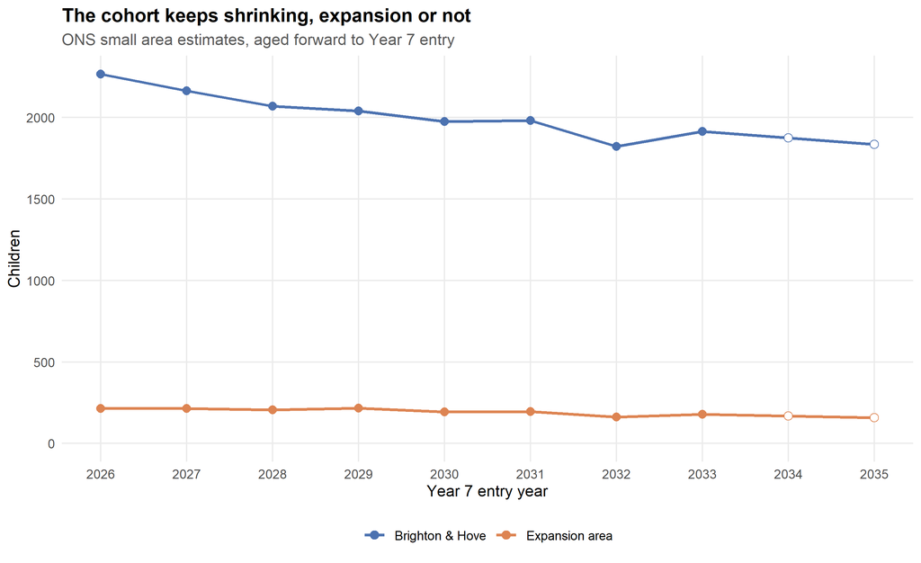

Projected state-sector Year 7 demand. Solid points are cohort-aged from children already counted in the ONS mid-2022 estimates; open points from 2034 are extrapolated.

```r
inp$demand_ts %>%
  filter(entry_year >= 2026) %>%
  ggplot(aes(entry_year, state_demand, colour = area)) +
  geom_line(linewidth = 0.9) +
  geom_point(aes(shape = extrapolated), size = 2.6, fill = "white") +
  scale_shape_manual(values = c(`FALSE` = 16, `TRUE` = 21), guide = "none") +
  scale_colour_manual(values = c("Brighton & Hove" = "#4C72B0",
                                 "Expansion area" = "#DD8452")) +
  scale_x_continuous(breaks = seq(2026, 2035, 1)) +
  expand_limits(y = 0) +
  labs(title = "The cohort keeps shrinking, expansion or not",
       subtitle = "ONS small area estimates, aged forward to Year 7 entry",
       x = "Year 7 entry year", y = "Children", colour = NULL) +
  theme(legend.position = "bottom")
```

A second, independently grounded projection from Reception offers is set out in Section 14.1.

A child aged $a$ in the ONS mid-2022 estimates enters Year 7 in $2022 + (11 - a)$, so entry years to 2033 come from children already born and counted. Only 2034 and 2035 are extrapolated.

Brighton & Hove’s Year 7 cohort falls from about 2,267 in 2026 to 1,835 in 2035 — a drop of **19%**. The expansion area adds 215 children in 2026 and 158 by 2035.

## 14.1 A second projection, from children already in school

The projection above counts children *in the population*. What schools need is children who will take a *state-sector* place, and the gap between the two — independent schools, home education, migration — is large in Brighton.

There is a better-grounded alternative in the published record, and it is the method already used in [brighton_and_hove_allocations](https://adamdennett.github.io/BH_Schools_2/brighton_and_hove_allocations.html): compare Reception offers with the Year 7 offers made to the **same cohort** seven years later. A child offered a Reception place in 2014 was offered a Year 7 place in 2021. The ratio between them is a measured survival rate, not an assumption.

```r
rec$cohort %>%
  transmute(`Reception year` = cohort_year,
            `Reception offers` = rec_offers,
            `Year 7 year` = y7_year,
            `Year 7 offers` = y7_offers,
            Change = change,
            `Survival` = sprintf("%.3f", survival)) %>%
  tbl(caption = "The same cohort, at ages 4 and 11")
```

The same cohort, at ages 4 and 11

| Reception year | Reception offers | Year 7 year | Year 7 offers | Change | Survival |
| --- | --- | --- | --- | --- | --- |
| 2014 | 2,731 | 2021 | 2451 | -280 | 0.897 |
| 2015 | 2,686 | 2022 | 2336 | -350 | 0.870 |
| 2016 | 2,686 | 2023 | 2342 | -344 | 0.872 |
| 2017 | 2,538 | 2024 | 2229 | -309 | 0.878 |
| 2018 | 2,500 | 2025 | 2249 | -251 | 0.900 |
| 2019 | 2,492 | 2026 | 2250 | -242 | 0.903 |

The rate is remarkably steady: 0.884 across the five most recent cohorts, with a standard deviation of 0.016 and no significant trend (p = 0.38). About 12% of a Reception cohort has left the city’s state sector by Year 7.

Applying it to cohorts already sitting in primary school projects Year 7 demand to **2033 entry without extrapolating a single birth**:

```r
rec$comparison %>%
  transmute(`Entry year` = entry_year,
            `From Reception offers` = round(reception_based),
            `From ONS estimates` = round(ons_demand),
            Difference = round(diff),
            `%` = sprintf("%+.1f%%", pct),
            Note = if_else(extrapolated, "ONS figure extrapolated", "")) %>%
  tbl(caption = "Two independent projections of Year 7 demand")
```

Two independent projections of Year 7 demand

| Entry year | From Reception offers | From ONS estimates | Difference | % | Note |
| --- | --- | --- | --- | --- | --- |
| 2027 | 2,143 | 2,164 | -21 | -1.0% |  |
| 2028 | 2,081 | 2,070 | 11 | +0.5% |  |
| 2029 | 1,987 | 2,041 | -55 | -2.7% |  |
| 2030 | 1,894 | 1,975 | -81 | -4.1% |  |
| 2031 | 1,927 | 1,982 | -55 | -2.8% |  |
| 2032 | 1,805 | 1,823 | -18 | -1.0% |  |
| 2033 | 1,750 | 1,916 | -165 | -8.6% |  |

## 14.2 What the council itself projects

```r
rec$council %>%
  select(CatchmentGroup, PAN, entry_year, council) %>%
  pivot_wider(names_from = entry_year, values_from = council) %>%
  rename(Catchment = CatchmentGroup) %>%
  tbl(caption = "Brighton & Hove's own Oct-2025 Year 7 forecast, by catchment")
```

Brighton & Hove's own Oct-2025 Year 7 forecast, by catchment

| Catchment | PAN | 2026 | 2027 | 2028 | 2029 | 2030 | 2031 | 2032 |
| --- | --- | --- | --- | --- | --- | --- | --- | --- |
| PACA | 220 | 218 | 178 | 194 | 179 | 212 | 147 | 173 |
| Hove Park / Blatchington Mill | 510 | 424 | 438 | 390 | 410 | 351 | 373 | 311 |
| Varndean / Dorothy Stringer | 630 | 601 | 588 | 563 | 530 | 543 | 527 | 496 |
| Longhill | 210 | 162 | 148 | 160 | 146 | 129 | 148 | 100 |
| BACA | 180 | 128 | 135 | 138 | 112 | 97 | 121 | 103 |
| Patcham | 225 | 194 | 203 | 200 | 185 | 168 | 172 | 162 |

Two things in the council’s own forecast deserve more attention than they have had.

**It plans around a Longhill PAN of 210.** The adjudicator has since confirmed that number as binding for 2026/27, and it is the one used throughout this document. The 240 that appears alongside it in places is the figure Longhill carried until 2026, kept for comparison rather than as a live option.

**Its 2032 figure for the Longhill catchment is 100 children** — against that PAN of 210, a shortfall of 110. Across 2026 to 2032 the council’s Longhill line falls -38%.

**WarningMost of that decline is an assumption, not a demographic**

The council’s forecast reduces each catchment’s roll by a catchment-specific rate for children expected to leave the state-maintained sector. Published in the same appendix, those rates are: PACA 2.46%, Hove Park / Blatchington Mill 5.13%, Varndean / Dorothy Stringer 4.58%, BACA 6.52%, Patcham 3.03% — and **Longhill 23.89%**, more than five times the average of the other five. That assumption is tested against published evidence in Section 14.3.

The Reception cohorts actually feeding the Longhill catchment fall by about 24% over the same span. The council’s line falls roughly twice as fast, and the difference is that single leakage rate.

The assumption may well be right — Longhill does lose a great many children to other schools, which is the entire subject of this document. But it is close to self-fulfilling as a planning device: a high leakage rate justifies shrinking the school, and a shrinking school raises leakage. It deserves to be stated as a judgement and tested, rather than carried through as a parameter.

### 14.2.1 Every catchment, side by side

The comparison above is worth doing for all six catchments rather than Longhill alone, because it shows how far Longhill’s treatment stands apart. This replicates the cohort-ageing projection from [*Brighton and Hove allocations*](https://adamdennett.github.io/BH_Schools_2/brighton_and_hove_allocations.html#our-own-projection-cohort-aging-from-primary-allocations), which ages each catchment’s Reception offers forward seven years to the Year 7 cohort they become.

```r
# Our internal catchment keys and the council's published labels name the
# same places. They must be harmonised before any join, or the two paired
# catchments silently drop out of every comparison below.
CATCH_LABEL <- c(PACA = "PACA",
                 Hove_Blatch = "Hove Park / Blatchington Mill",
                 Patcham = "Patcham",
                 DS_Varndean = "Varndean / Dorothy Stringer",
                 BACA = "BACA",
                 Longhill = "Longhill",
                 Peacehaven = "Peacehaven",
                 `Religious schools` = "Religious schools")
relabel <- function(x) dplyr::coalesce(unname(CATCH_LABEL[x]), x)

ours_lab <- rec$by_catchment %>% mutate(catchment = relabel(catchment))
council_lab <- rec$council %>%
  transmute(catchment = relabel(CatchmentGroup), entry_year, council)

cp <- ours_lab %>%
  filter(entry_year %in% c(2026, 2029, 2032)) %>%
  select(catchment, entry_year, ours = projected) %>%
  left_join(council_lab, by = c("catchment", "entry_year")) %>%
  filter(!is.na(council))

stopifnot(dplyr::n_distinct(cp$catchment) == 6)

cp %>%
  mutate(txt = sprintf("%d / %d", round(ours), round(council))) %>%
  select(catchment, entry_year, txt) %>%
  pivot_wider(names_from = entry_year, values_from = txt) %>%
  rename(Catchment = catchment) %>%
  tbl(caption = "Children aged forward from Reception offers / the council's own forecast, by catchment and entry year")
```

Children aged forward from Reception offers / the council's own forecast, by catchment and entry year

| Catchment | 2026 | 2029 | 2032 |
| --- | --- | --- | --- |
| BACA | 122 / 128 | 92 / 112 | 108 / 103 |
| Varndean / Dorothy Stringer | 610 / 601 | 550 / 530 | 499 / 496 |
| Hove Park / Blatchington Mill | 470 / 424 | 424 / 410 | 387 / 311 |
| Longhill | 110 / 162 | 105 / 146 | 84 / 100 |
| PACA | 186 / 218 | 153 / 179 | 129 / 173 |
| Patcham | 205 / 194 | 195 / 185 | 168 / 162 |

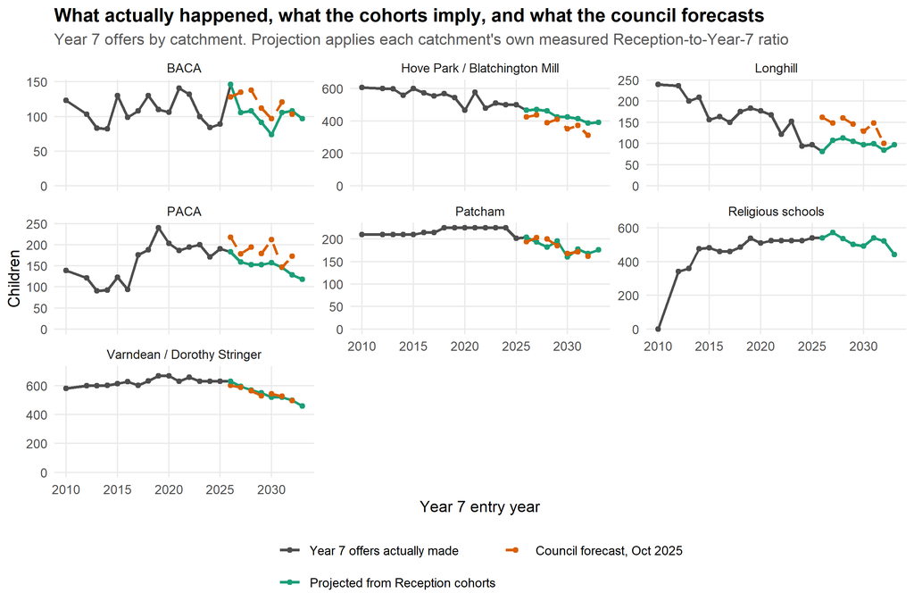

```r
LV <- c("Year 7 offers actually made", "Projected from Reception cohorts",
        "Council forecast, Oct 2025")

pj <- bind_rows(
  rec$observed_by_catchment %>%
    transmute(catchment, entry_year, n = y7_offers, src = LV[1]),
  rec$by_catchment %>%
    filter(entry_year > max(rec$observed_by_catchment$entry_year)) %>%
    transmute(catchment, entry_year, n = projected, src = LV[2]),
  rec$council %>%
    transmute(catchment = CatchmentGroup, entry_year, n = council, src = LV[3])) %>%
  filter(!is.na(n)) %>%
  mutate(catchment = relabel(catchment), src = factor(src, levels = LV))

# Join the observed series to the projection so the line is continuous
# rather than breaking at the handover year.
bridge <- rec$observed_by_catchment %>%
  filter(entry_year == max(entry_year)) %>%
  transmute(catchment = relabel(catchment), entry_year, n = y7_offers,
            src = factor(LV[2], levels = LV))

# Free y-scales otherwise crop the taller panels awkwardly. These are
# headroom values, not data.
ylim_df <- tibble(
  catchment = c("Hove Park / Blatchington Mill", "Varndean / Dorothy Stringer",
                "Religious schools"),
  n = c(625, 700, 600), entry_year = 2026,
  src = factor(LV[1], levels = LV))

bind_rows(pj, bridge) %>%
  ggplot(aes(entry_year, n, colour = src, linetype = src)) +
  geom_line(linewidth = 0.9) + geom_point(size = 1.5) +
  geom_blank(data = ylim_df) +
  facet_wrap(~ catchment, ncol = 3, scales = "free_y") +
  scale_colour_manual(values = setNames(c("grey30", "#1b9e77", "#d95f02"), LV)) +
  scale_linetype_manual(values = setNames(c("solid", "solid", "dashed"), LV)) +
  expand_limits(y = 0) +
  labs(title = "What actually happened, what the cohorts imply, and what the council forecasts",
       subtitle = "Year 7 offers by catchment. Projection applies each catchment's own measured Reception-to-Year-7 ratio",
       x = "Year 7 entry year", y = "Children", colour = NULL, linetype = NULL) +
  theme(legend.position = "bottom") +
  guides(colour = guide_legend(nrow = 2), linetype = guide_legend(nrow = 2))
```

The pattern is easier to see as the gap itself — the council’s forecast expressed as a percentage of the children the Reception cohorts imply.

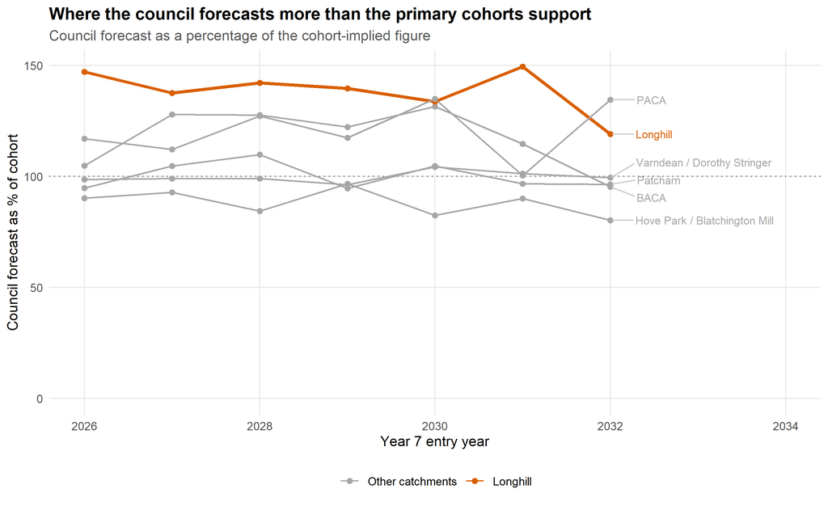

The council’s forecast as a share of the cohort implied by each catchment’s own conversion rate. Above 100% means the council is forecasting more children than the primary cohorts support.

```r
gap <- ours_lab %>%
  select(catchment, entry_year, ours = projected) %>%
  inner_join(council_lab, by = c("catchment", "entry_year")) %>%
  mutate(ratio = 100 * council / ours,
         lh = catchment == "Longhill")

gap %>%
  ggplot(aes(entry_year, ratio, group = catchment, colour = lh)) +
  geom_hline(yintercept = 100, linetype = "dotted", colour = "grey50") +
  geom_line(aes(linewidth = lh)) + geom_point(size = 1.8) +
  scale_colour_manual(values = c(`TRUE` = "#d95f02", `FALSE` = "grey65"),
                      labels = c(`TRUE` = "Longhill", `FALSE` = "Other catchments")) +
  scale_linewidth_manual(values = c(`TRUE` = 1.2, `FALSE` = 0.6), guide = "none") +
  ggrepel::geom_text_repel(
    data = gap %>% filter(entry_year == max(entry_year)),
    aes(label = catchment), size = 3, hjust = 0, direction = "y",
    nudge_x = 0.3, segment.colour = "grey80", show.legend = FALSE) +
  scale_x_continuous(limits = c(2026, 2034)) +
  expand_limits(y = 0) +
  labs(title = "Where the council forecasts more than the primary cohorts support",
       subtitle = "Council forecast as a percentage of the cohort-implied figure",
       x = "Year 7 entry year", y = "Council forecast as % of cohort", colour = NULL) +
  theme(legend.position = "bottom")
```

**ImportantThe council’s forecast is above what Longhill’s own primary cohorts support, in every year**

The ratio matters more than the raw cohort here, and it is measured rather than assumed. For each catchment it is the Year 7 offers made *by that catchment’s own secondaries*, over the Reception offers made in that catchment seven years earlier — so it absorbs leakage, cross-catchment movement and capacity limits in one observed number.

```r
rec$by_catchment %>% distinct(catchment, surv_catch) %>%
  transmute(Catchment = catchment, `Reception-to-Year-7 ratio` = round(surv_catch, 3)) %>%
  arrange(`Reception-to-Year-7 ratio`) %>%
  tbl(caption = "Share of each catchment's Reception cohort that reaches that catchment's own secondary schools")
```

Share of each catchment's Reception cohort that reaches that catchment's own secondary schools

| Catchment | Reception-to-Year-7 ratio |
| --- | --- |
| Longhill | 0.503 |
| Hove_Blatch | 0.647 |
| PACA | 0.770 |
| DS_Varndean | 0.808 |
| Patcham | 0.832 |
| BACA | 1.272 |
| Religious schools | 2.562 |

**Longhill retains 50% of its Reception children — the lowest in the city, against a city-wide figure of 88%.** Fewer than half the children starting primary school in the Longhill catchment take a Year 7 place at Longhill. Brighton Aldridge, at the other extreme, recruits more than its own catchment produces.

**This is where the sleepwalking risk actually sits.** The council’s forecast already looks pessimistic about Longhill relative to other catchments, and it is *still* not pessimistic enough. Its 23.89% leakage deduction is applied to a cohort figure that assumes Longhill converts its catchment at something like the city-wide rate. It does not, and has not for at least six years.

The calibrated behavioural model reaches the same place independently and goes further: around 79 children by 2035, below both lines above.

Two consequences follow. First, decisions about Longhill’s admission number are being taken against a demand figure that the school’s own primary catchment does not support. Second, using leakage as the sole adjustment is self-reinforcing as a planning device — a high assumed leakage justifies shrinking the school, and a shrinking school raises leakage — while never asking the question that matters, which is *what would change the conversion rate*.

## 14.3 The assumption is testable, and the adjudicator published the test

When the Office of the Schools Adjudicator determined objections to the 2026/27 arrangements on 20 October 2025 (ADA4423, ADA4452–4454, ADA4456, ADA4458), it required the council to produce evidence, and published it. One of those tables answers the question directly: how many children in each catchment are offered a place **outside** Brighton & Hove.

```r
adj$outside %>%
  transmute(Catchment = catchment, round,
            v = sprintf("%d (%.0f%%)", children, share)) %>%
  pivot_wider(names_from = round, values_from = v) %>%
  tbl(caption = paste0(
    "Children offered a place outside Brighton & Hove on National Offer Day, ",
    "by home catchment. Percentages are of the city-wide total that year. ",
    "Source: adjudicator's determination, ", format(adj$determined, "%d %B %Y"),
    ", Table 11."))
```

Children offered a place outside Brighton & Hove on National Offer Day, by home catchment. Percentages are of the city-wide total that year. Source: adjudicator's determination, 20 October 2025, Table 11.

| Catchment | 2023/24 | 2024/25 | 2025/26 |
| --- | --- | --- | --- |
| PACA | 3 (5%) | 3 (4%) | 9 (12%) |
| Hove_Blatch | 3 (5%) | 7 (10%) | 7 (9%) |
| Patcham | 2 (3%) | 1 (1%) | 0 (0%) |
| DS_Varndean | 2 (3%) | 5 (7%) | 1 (1%) |
| BACA | 3 (5%) | 5 (7%) | 3 (4%) |
| Longhill | 50 (79%) | 46 (69%) | 54 (73%) |

**The Longhill catchment accounts for 69–79% of every child who leaves Brighton & Hove for a school elsewhere.** In the most recent round it was 54 children of 74 city-wide. Every other catchment loses single figures.

This is the strongest published evidence in this document, and it changes what can be said. The council’s 23.89% leakage assumption is not an arbitrary planning parameter — it is measuring something real and specific, concentrated almost entirely in one catchment. Set against a Longhill catchment cohort of roughly 290 children, 54 leavers is about 19%, which is the same order as the rate the council applies.

The council’s own forecast makes the same point from the other direction:

```r
adj$retention %>%
  transmute(Catchment = catchment, round, v = sprintf("%.0f%%", retained)) %>%
  pivot_wider(names_from = round, values_from = v) %>%
  tbl(caption = "Share of each catchment's forecast children expected at its own schools. Source: determination, Table 9.")
```

Share of each catchment's forecast children expected at its own schools. Source: determination, Table 9.

| Catchment | 2026/27 | 2027/28 | 2028/29 | 2029/30 | 2030/31 | 2031/32 |
| --- | --- | --- | --- | --- | --- | --- |
| PACA | 84% | 81% | 82% | 81% | 83% | 78% |
| Hove_Blatch | 58% | 58% | 57% | 57% | 53% | 54% |
| Patcham | 85% | 85% | 85% | 84% | 82% | 84% |
| DS_Varndean | 86% | 86% | 85% | 85% | 85% | 85% |
| BACA | 78% | 79% | 79% | 76% | 74% | 78% |
| Longhill | 58% | 57% | 58% | 57% | 56% | 56% |

Longhill’s catchment is forecast to retain 56–58% of its children at its own school, against 85–86% for Stringer and Varndean. Part of that gap is the two city-wide faith schools, which draw from everywhere; the rest is the outflow above.

**ImportantThis is the largest single lever available, and it is not a catchment lever**

Roughly 54 children a year leave the city from one catchment. That is more than the entire effect of the 2028 boundary change, more than any admission-number reduction elsewhere in the city, and more than the modelled effect of the 2024 catchment redraw.

It is also the only quantity in this document whose value does not shrink as the cohort shrinks, because retaining a child **adds** to the system rather than moving a child within it. Every other lever tested here redistributes.

What it would take to reverse it is a question about why families in the east choose to travel out of the city, which no spatial model answers — the journey times in Section 3.3 show these are not families being driven out by distance. It is the question the council’s own evidence most clearly raises and least clearly addresses.

# 15 The 2028 boundary change

On 16 July 2026 the Local Government Secretary confirmed that Brighton & Hove’s boundary will expand eastward from **1 April 2028** to take in East Saltdean, Telscombe and Peacehaven. Falmer, which had been under consideration, was dropped.

```r
wards_wgs <- st_transform(os$wards, 4326)

pip_sf <- os$pip %>%
  left_join(inp$schools %>% select(name, easting, northing), by = "name") %>%
  filter(!is.na(easting)) %>%
  bind_rows(
    tibble(name = "Seahaven Academy", la = "East Sussex", roll = 769,
           joins = FALSE, dist_km = os$pip$dist_km[os$pip$name == "Seahaven Academy"],
           easting = 543952, northing = 100605)
  ) %>%
  distinct(name, .keep_all = TRUE) %>%
  st_as_sf(coords = c("easting", "northing"), crs = 27700) %>% st_transform(4326)

leaflet() %>%
  addProviderTiles(providers$CartoDB.Positron) %>%
  addPolygons(data = catch_sf, fillOpacity = 0.06, color = "#8172B3", weight = 1.5,
              label = ~catchment, group = "Current catchments") %>%
  addPolygons(data = wards_wgs, fillColor = "#DD8452", fillOpacity = 0.35,
              color = "#DD8452", weight = 2, label = ~WD25NM,
              popup = ~paste0("<b>", WD25NM, "</b><br>Joins Brighton & Hove April 2028"),
              group = "Joining in 2028") %>%
  addCircleMarkers(data = pip_sf %>% filter(!joins), radius = 6, color = "grey35",
                   weight = 2, fillOpacity = 0, label = ~name,
                   popup = ~paste0("<b>", name, "</b><br>", la,
                                   "<br><i>Stays outside</i>")) %>%
  addCircleMarkers(data = pip_sf %>% filter(joins), radius = 9, color = "black",
                   weight = 2, fillColor = "#2ca02c", fillOpacity = 0.9,
                   label = ~name,
                   popup = ~paste0("<b>", name, "</b><br>", la,
                                   "<br><b>Inside the new boundary</b>")) %>%
  addLayersControl(overlayGroups = c("Current catchments", "Joining in 2028"),
                   options = layersControlOptions(collapsed = FALSE))
```

[interactive chart not shown]

The expanded authority. Orange are the four wards joining in 2028. Filled circles are secondary schools inside the new boundary; hollow ones stay outside.

```r
os$pip %>%
  filter(joins | dist_km < 7) %>%
  transmute(School = name, `Local authority` = la, Postcode = postcode, Roll = roll,
            Verdict = if_else(joins, "JOINS Brighton & Hove",
                              paste0("Stays outside — ", sprintf("%.2f km", dist_km),
                                     " from the new boundary"))) %>%
  tbl(caption = "Secondary schools and the 2028 boundary (point-in-polygon test)") %>%
  row_spec(1, bold = TRUE, background = "#e8f5e9")
```

Secondary schools and the 2028 boundary (point-in-polygon test)

| School | Local authority | Postcode | Roll | Verdict |
| --- | --- | --- | --- | --- |
| Peacehaven Community School | East Sussex | BN10 8RB | 917 | JOINS Brighton & Hove |
| Seahaven Academy | East Sussex | BN9 9TD | 769 | Stays outside — 0.67 km from the new boundary |
| Longhill High School | Brighton and Hove | BN2 7FR | 825 | Stays outside — 2.93 km from the new boundary |
| Priory School | East Sussex | BN7 2XN | 1,154 | Stays outside — 5.62 km from the new boundary |
| Seaford Head School | East Sussex | BN25 4LX | 1,408 | Stays outside — 6.31 km from the new boundary |

A point-in-polygon test against the four ward boundaries settles a question that is often muddled: **Peacehaven Community School is inside. Seahaven Academy is not** — it sits in Newhaven, 0.67 km beyond the eastern edge, and none of the four wards reaches it. The two towns are adjacent; only one is moving.

So Brighton & Hove acquires **one** secondary school and roughly 215 Year 7 children a year. Peacehaven Community School has 917 pupils against a GIAS capacity of 890 — it is full. **The city is not gaining an unserved population; it is gaining a served one, with its school attached.**

# 16 Is there a viable school at Ovingdean?

## 16.1 The money

```r
os$lh_fin %>%
  transmute(Year = year_label, Roll = roll,
            `Income per pupil` = paste0("£", fmt(income_pp)),
            `Spend per pupil` = paste0("£", fmt(expenditure_pp)),
            `In-year balance` = paste0("£", fmt(balance)),
            `Revenue reserve` = paste0("£", fmt(reserve))) %>%
  tbl(caption = "Longhill High School, from the published DfE financial returns")
```

Longhill High School, from the published DfE financial returns

| Year | Roll | Income per pupil | Spend per pupil | In-year balance | Revenue reserve |
| --- | --- | --- | --- | --- | --- |
| 2021-22 | 908 | £7,644 | £6,980 | £602,810 | £960,852 |
| 2022-23 | 875 | £7,978 | £7,998 | £-17,469 | £943,383 |
| 2023-24 | 825 | £8,748 | £9,041 | £-243,505 | £699,878 |
| 2024-25 | 723 | £10,358 | £10,591 | £-168,435 | £531,443 |

Longhill is not short of money per pupil. Its income per pupil rose to **£10,358**, among the highest of any secondary school in the city, precisely *because* its roll is falling faster than its funding. What it cannot do is spend less: it has run an in-year deficit for three consecutive years and its reserves have fallen from £960,852 to £531,443.

**At the average burn of £143,136 a year, the remaining reserve lasts about 4 more years** — around 2029, the year after the boundary change takes effect and four years before its first Year 7 cohort would reach Year 11.

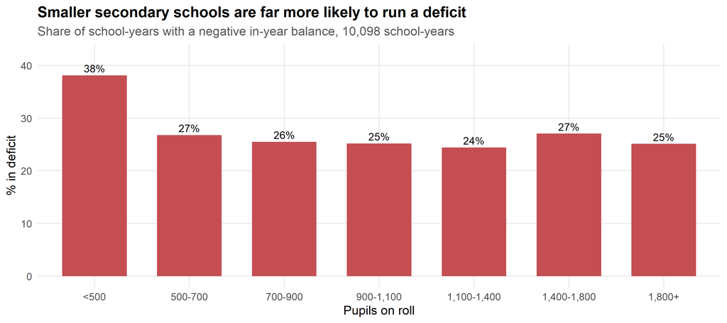

Financial health by school size, all English state secondaries, 2021-22 to 2024-25.

```r
os$size_fin %>%
  ggplot(aes(size_band, pct_deficit)) +
  geom_col(fill = "#c44e52", width = 0.68) +
  geom_text(aes(label = paste0(round(pct_deficit), "%")), vjust = -0.4, size = 3.3) +
  expand_limits(y = 42) +
  labs(title = "Smaller secondary schools are far more likely to run a deficit",
       subtitle = paste0("Share of school-years with a negative in-year balance, ",
                         fmt(sum(os$size_fin$n)), " school-years"),
       x = "Pupils on roll", y = "% in deficit")
```

This is not unique to Longhill. Across 10,098 school-years of English secondary finance returns, schools under 500 pupils run a deficit 38% of the time against about 25% for everyone else — despite receiving more per pupil. A secondary school staffs a maths, science and languages department whether its year group is 90 or 240.

## 16.2 What size of school does the demand support?

**NoteWhat “1,728 runs” means — and what it does not**

The figures in this section come from running the model many times. It is worth saying plainly what is being varied, because the phrasing invites a misunderstanding.

**Nothing here is random.** There is no simulation, no draw, no Monte Carlo, and no stochastic element of any kind. Every run is the same deterministic model, evaluated once at one specific combination of settings. Run it twice with the same settings and you get the same answer to the last decimal.

What varies is the **assumptions**, and they are varied exhaustively rather than sampled. The model has three inputs that published data cannot pin down, so each is stepped across its plausible range and every combination is evaluated:

```r
tibble::tibble(
  Input = c("Distance decay (β)", "Catchment priority (γ)",
            "Attractiveness specification", "Longhill site",
            "Entry year"),
  `Values tried` = c(
    sprintf("%d, from %.1f to %.1f", length(env$betas), min(env$betas), max(env$betas)),
    sprintf("%d, from %.1f to %.1f", length(env$gammas), min(env$gammas), max(env$gammas)),
    sprintf("%d (%s)", length(env$w_specs), paste(env$w_specs, collapse = ", ")),
    "2 (Ovingdean, Elm Grove)",
    sprintf("%d (%s)", length(unique(env$envelope$entry_year)),
            paste(sort(unique(env$envelope$entry_year)), collapse = ", "))),
  n = c(length(env$betas), length(env$gammas), length(env$w_specs), 2,
        length(unique(env$envelope$entry_year)))) %>%
  select(-n) %>%
  tbl(caption = sprintf("The grid. Multiplying the counts gives %s combinations.", fmt(nrow(env$envelope))))
```

The grid. Multiplying the counts gives 1,728 combinations.

| Input | Values tried |
| --- | --- |
| Distance decay (β) | 18, from 1.5 to 3.2 |
| Catchment priority (γ) | 4, from 0.0 to 2.4 |
| Attractiveness specification | 4 (W_equal, W_pan, W_prefs, W_att8) |
| Longhill site | 2 (Ovingdean, Elm Grove) |
| Entry year | 3 (2026, 2030, 2035) |

18 × 4 × 4 × 2 × 3 = **1,728**. That is the whole of it: a full factorial grid, not a sample from one.

**Why do it this way.** With individual admissions records these three inputs would be estimated, and the model would be run once with the fitted values. That is not available (Section 6), so instead of guessing a value and presenting a single number as though it were known, the analysis reports what happens across *every* value the evidence permits. A conclusion that holds at all 1,728 combinations does not depend on the guess. One that holds at some and not others is flagged as depending on it, and the variance table below says which input it depends on most.

So the ranges quoted throughout are **not confidence intervals** and carry no probability. They are the span of answers the model gives across the assumptions that cannot be ruled out — which is a weaker claim than a confidence interval, and an honest one.

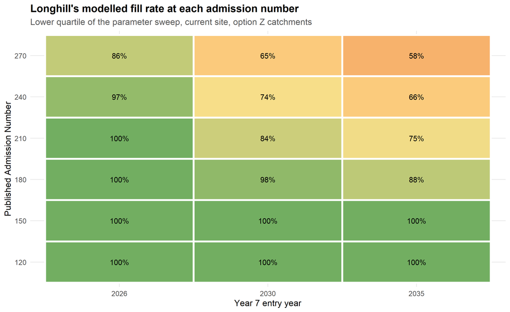

Modelled fill rate by admission number. Green is a school recruiting to its published number; red is a school that is not. Built to match the equivalent figure in the record-calibrated analysis, so the two can be read side by side.

```r
PAN_LADDER <- c(270, 240, 210, 180, 150, 120)

fill_open <- env$envelope %>%
  filter(site == "now") %>%
  group_by(entry_year) %>%
  # The lower quartile rather than the median. Every open specification
  # shares the same blind spot — none can see how strongly families avoid
  # a school — so they err in the same direction rather than scattering
  # either side of the truth. A central tendency across four specifications
  # biased the same way is still biased.
  summarise(intake = quantile(natural_intake, 0.25), .groups = "drop") %>%
  tidyr::crossing(pan = PAN_LADDER) %>%
  mutate(fill = intake / pan,
         lab  = paste0(round(100 * pmin(fill, 1)), "%"))

fill_open %>%
  ggplot(aes(factor(entry_year), factor(pan, levels = rev(PAN_LADDER)),
             fill = pmin(fill, 1.05))) +
  geom_tile(colour = "white", linewidth = 1.2) +
  geom_text(aes(label = lab), size = 3.4) +
  scale_fill_gradient2(low = "#d73027", mid = "#fee08b", high = "#1a9850",
                       midpoint = 0.72, limits = c(0.25, 1.05), guide = "none") +
  labs(title = "Longhill's modelled fill rate at each admission number",
       subtitle = "Lower quartile of the parameter sweep, current site, option Z catchments",
       x = "Year 7 entry year", y = "Published Admission Number")
```

This is the same figure, on the same axes and the same colour scale, as the one in the record-calibrated analysis — so the two can be compared directly rather than by translation. **The caution below is about the levels, not the construction.**

It reads the **lower quartile** of the sweep rather than the median, for the reason set out in Section 23: all four attractiveness specifications share the same blind spot, so they err in the same direction rather than scattering either side of the truth, and a central tendency across four specifications biased the same way is still biased. On the median every admission number of 180 and below reads 100% in every year, which is not a finding but an artefact of that bias. The quartile at least distinguishes between the options, which is what the figure is for.

The second view answers a different question, and it is the one published data is better placed to answer: not how full the school gets under one set of assumptions, but how often it reaches its number across *every* assumption in the sweep.

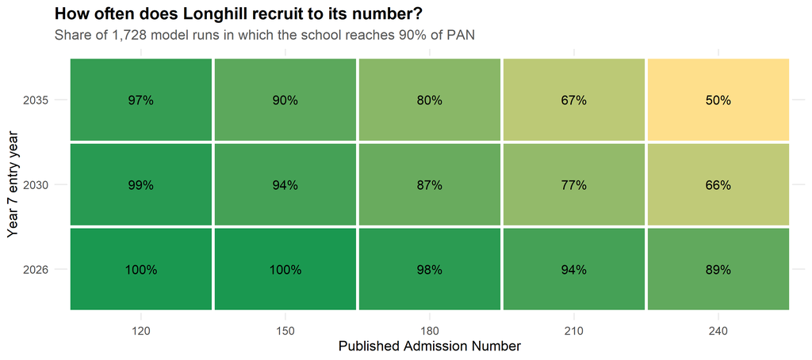

How often Longhill recruits to each admission number, across the full parameter sweep. This is the share of model RUNS reaching 90% of PAN, not a fill rate.

```r
env$q1 %>%
  pivot_longer(-entry_year, names_to = "pan", values_to = "pct") %>%
  mutate(pan = factor(parse_number(pan))) %>%
  ggplot(aes(pan, factor(entry_year), fill = pct)) +
  geom_tile(colour = "white", linewidth = 1.2) +
  geom_text(aes(label = paste0(round(pct), "%")), size = 3.6) +
  scale_fill_gradient2(low = "#d73027", mid = "#fee08b", high = "#1a9850",
                       midpoint = 50, limits = c(0, 100), guide = "none") +
  labs(title = "How often does Longhill recruit to its number?",
       subtitle = paste0("Share of ", fmt(nrow(env$envelope)),
                         " model runs in which the school reaches 90% of PAN"),
       x = "Published Admission Number", y = "Year 7 entry year")
```

This is the central result, and it does not depend on any assumption the reader has to accept. Across the **entire** parameter sweep:

- At the PAN of 210 now in force, Longhill reaches 90% of its number in **67%** of runs by
  2035. At the 240 it carried until 2026, that falls to **50%**.
- At 150, in 90%.
- At 120, in 97%.

**CautionThis result is likely to differ from the calibrated model — and the difference changes the recommendation**

**Read the chart above carefully: it does not show fill rates.** Each cell is the share of model *runs* in which Longhill reaches 90% of its number — a measure of how robust a conclusion is to the unknown parameters, not of how full the school gets. The equivalent chart in the calibrated analysis shows actual fill rate, and the two are easy to confuse because they are both percentages on a red-to-green grid.

The first figure above is now built to match the calibrated analysis exactly — same quantity, same admission-number ladder, same colour scale — so the two can be laid side by side. Doing that shows the gap plainly rather than leaving it to be inferred from two different metrics.

**What a fill rate would look like instead can be bounded rather than asserted.** Section 23 shows this model recruiting roughly twice what the lower end of its own sweep suggests. Carry that through and a PAN of 150 in 2035 could plausibly fill somewhere in the high fifties rather than reaching its number in nine runs out of ten; a PAN of 120 might sit in the low seventies. If the true fill rates are anywhere near that, **the conclusion this section invites — that 120 to 150 is sustainable — does not follow.** A school at 57% of a 150 PAN is not a viable school; it is a smaller version of the same problem.

The alternative is that the open model is closer to right and the school genuinely does support five forms of entry. Nothing in published data distinguishes those two futures, and they imply completely different decisions.

**Recommendation: this analysis should be re-run on the council’s admissions records before any decision is taken on Longhill’s admission number.** The question in front of the council is not a fine judgement between adjacent options. It is whether a school supports three forms of entry or five, and this document cannot answer it — not because the method is inadequate, but because the one input that would settle it is held by the authority and not published.

The work required is small. The records already exist; no new collection, no survey, no change of practice is needed. Fitting the model to observed flows is a day’s work for someone who has done it before, and it converts every band in this section into a number. **A decision of this consequence should not be taken against a figure that could plausibly be wrong by a factor of two, when the data that would fix it is sitting in the admissions system.**

Both the metric and the over-prediction described in Section 23 push in the same direction here, which is why the gap is so wide. **What survives is the ranking and the exclusion at the top**: 240 and 210 are not viable on either analysis, and smaller is better. What does not survive is the implication that 120 to 150 is comfortable. On the records it is the least bad option, not a solution.

# 17 What the 2024 redraw did

Before asking what a new catchment could do, it is worth pricing the one the city has already adopted. Every run in the sweep was repeated on both maps — same site, same decay, same attractiveness, same catchment strength, same entry year — so the redraw can be isolated.

```r
inp$regime_pop %>%
  mutate(children = round(children)) %>%
  pivot_wider(names_from = regime, values_from = children) %>%
  transmute(Catchment = catchment,
            `Pre-2024` = pre2024, `Option Z` = optionZ,
            Change = optionZ - pre2024) %>%
  arrange(Change) %>%
  tbl(caption = "Children entering Year 7 in 2026, by catchment, under each map")
```

Children entering Year 7 in 2026, by catchment, under each map

| Catchment | Pre-2024 | Option Z | Change |
| --- | --- | --- | --- |
| DS_Varndean | 643 | 615 | -28 |
| Hove_Blatch | 762 | 734 | -28 |
| Peacehaven | 215 | 215 | 0 |
| Longhill | 283 | 289 | 6 |
| Patcham | 203 | 218 | 15 |
| PACA | 243 | 260 | 17 |
| BACA | 133 | 151 | 18 |

The headcount barely moves: Longhill’s catchment gains about 6 children. What changes is who they are. The zones moving *in* are no closer to Longhill than those moving *out* — both average about 34 minutes away — but they are markedly closer to the alternatives:

```r
mv <- inp$zones %>%
  filter(catch_pre2024 != catch_optionZ,
         catch_pre2024 == "Longhill" | catch_optionZ == "Longhill") %>%
  mutate(dir = if_else(catch_optionZ == "Longhill",
                       "Moves in (Kemptown)", "Moves out (Whitehawk & Marina)"))

inp$costs_now %>%
  filter(name %in% c(LH, "Dorothy Stringer School", "Varndean School")) %>%
  inner_join(mv %>% select(zone, dir, Oi), by = "zone") %>%
  group_by(dir, name) %>%
  summarise(mins = round(weighted.mean(cij, Oi), 1), .groups = "drop") %>%
  pivot_wider(names_from = dir, values_from = mins) %>%
  rename(School = name) %>%
  tbl(caption = "Population-weighted journey time from the areas the redraw moves")
```

Population-weighted journey time from the areas the redraw moves

| School | Moves in (Kemptown) | Moves out (Whitehawk & Marina) |
| --- | --- | --- |
| Dorothy Stringer School | 49.4 | 56.0 |
| Longhill High School | 33.3 | 34.0 |
| Varndean School | 43.6 | 48.8 |

```r
env$q6 %>%
  filter(site == "now") %>%
  group_by(entry_year) %>%
  summarise(Median = round(median(shift), 1),
            Lowest = round(min(shift), 1),
            Highest = round(max(shift), 1),
            `% of runs worse` = round(100 * mean(shift < 0)),
            .groups = "drop") %>%
  rename(`Entry year` = entry_year) %>%
  tbl(caption = "Change in Longhill's modelled recruitment under option Z, against the pre-2024 map")
```

Change in Longhill's modelled recruitment under option Z, against the pre-2024 map

| Entry year | Median | Lowest | Highest | % of runs worse |
| --- | --- | --- | --- | --- |
| 2026 | 0 | -3.4 | 4.8 | 28 |
| 2030 | 0 | -3.1 | 2.5 | 38 |
| 2035 | 0 | -2.1 | 1.9 | 42 |

That is itself worth reporting. The redraw is exactly the kind of change whose effect depends on how families actually behave, not on how far apart things are, and behaviour is the thing published statistics do not record. An origin–destination matrix of preferences by area would settle it immediately.

# 18 Shrink, move, or redraw?

**CautionThis result is likely to differ from the calibrated model**

The fill rates below inherit the over-prediction described under the chart in this section: because the open model recruits roughly twice as many children to Longhill as the records support, **every fill rate here is too high**, and the PAN at which the school appears viable is correspondingly too large.

**How much too high is the open question.** If the over-prediction runs at the factor the envelope’s own lower bound implies, configuration A would land somewhere near 40% by 2035 rather than anything approaching viable, and only the smallest configuration — Elm Grove at PAN 120 with redrawn catchments — would hold above 80% across the window. On the figures printed here several configurations look survivable at PAN 150; on that reading they would not be.

What survives either reading is the *comparative* finding, and it is the one the policy question turns on: moving and redrawing are worth little separately and considerably more together, and no configuration rescues a PAN of 210. Read the rank order with confidence; treat the levels as an upper bound.

**Recommendation: the council should have these configurations re-run against its own records before committing to any of them.** The rank order here is reliable enough to shortlist with. The levels are not reliable enough to choose with — and choosing is what the next admissions round requires. A configuration that looks survivable on these figures and is not on the records would commit the city to a school size that fails within a decade, and the difference between those two readings is one dataset the authority already holds.

```r
os$lh_band %>%
  filter(entry_year %in% c(2026, 2030, 2035)) %>%
  mutate(txt = sprintf("%.0f (%.0f–%.0f)", 100*pmin(central,1),
                       100*pmin(lo,1), 100*pmin(hi,1))) %>%
  select(config, entry_year, txt) %>%
  pivot_wider(names_from = entry_year, values_from = txt) %>%
  rename(Configuration = config) %>%
  tbl(caption = "Longhill fill rate (%) — central specification, with the range across the parameter band in brackets")
```

Longhill fill rate (%) — central specification, with the range across the parameter band in brackets

| Configuration | 2026 | 2030 | 2035 |
| --- | --- | --- | --- |
| A. Today: Ovingdean, PAN 210, current catchments | 100 (74–100) | 83 (45–100) | 74 (39–100) |
| B. Shrink only: Ovingdean, PAN 150 | 100 (100–100) | 100 (63–100) | 100 (55–100) |
| C. Move only: Elm Grove, PAN 210 | 100 (92–100) | 97 (57–100) | 86 (50–100) |
| D. Shrink + move: Elm Grove, PAN 150 | 100 (100–100) | 100 (80–100) | 100 (70–100) |
| E. Shrink + move + redrawn catchments | 100 (100–100) | 100 (86–100) | 100 (74–100) |
| F. Redrawn catchments, Longhill stays at Ovingdean | 100 (100–100) | 100 (67–100) | 90 (55–100) |
| G. Elm Grove, PAN 120, redrawn catchments | 100 (100–100) | 100 (100–100) | 100 (92–100) |

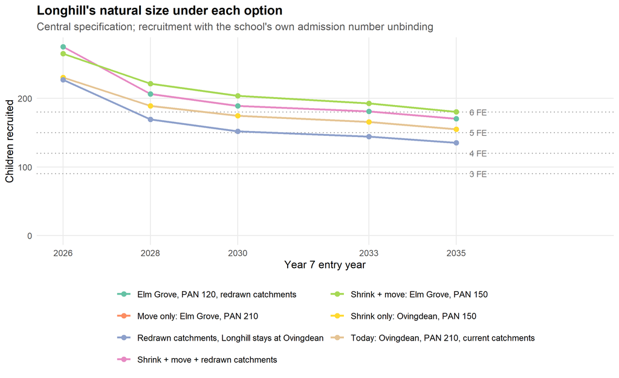

Longhill’s natural recruitment under each configuration at the central specification. Dotted lines are whole forms of entry.

```r
os$natural %>%
  mutate(lab = str_remove(config, "^[A-G]\\. ")) %>%
  ggplot(aes(entry_year, natural, colour = lab, group = lab)) +
  geom_hline(yintercept = c(90, 120, 150, 180), linetype = "dotted", colour = "grey60") +
  annotate("text", x = 2035.3, y = c(90, 120, 150, 180),
           label = c("3 FE", "4 FE", "5 FE", "6 FE"), hjust = 0, size = 3, colour = "grey45") +
  geom_line(linewidth = 0.9) + geom_point(size = 2.2) +
  scale_x_continuous(breaks = os$years, limits = c(2026, 2038)) +
  scale_colour_brewer(palette = "Set2") +
  expand_limits(y = 0) +
  labs(title = "Longhill's natural size under each option",
       subtitle = "Central specification; recruitment with the school's own admission number unbinding",
       x = "Year 7 entry year", y = "Children recruited", colour = NULL) +
  theme(legend.position = "bottom") +
  guides(colour = guide_legend(nrow = 4))
```

**CautionThis chart is the most optimistic thing in the report, and it is wrong in a known direction**

**Read the level on this chart with great care.** It is where this model is most likely to be wrong, and the direction of the error is knowable even if its size is not.

The chart puts Longhill’s 2035 recruitment at **155** children where it stands today. The bottom of the sweep in Section 23 puts the same figure near **78** — less than half. That is the range a calibrated model would resolve, and there is good reason to think it would land towards the lower end.

**Why.** The open model can see how reachable Longhill is but has nothing that measures how strongly families *avoid* it. Published data records where children were offered places, not what they wanted. Once routed journey times let the model see that Longhill is genuinely accessible, it sends children there in numbers the city’s actual admissions do not bear out — the validation below shows exactly that over-prediction.

**What that would mean.** If the true figures sit near the lower bound, every curve here moves down by something approaching a factor of two, and the conclusion hardens considerably: no configuration would have Longhill recruiting above four forms of entry after 2030, and the current arrangement would fall below three. The *ordering* would be largely preserved — relocation and redrawing still help, in the same rank order — so the comparative reading survives either way. **The level does not.**

Treat the shape of this chart as informative and the height of it as an upper bound.

**ImportantRelocation helps — a correction to an earlier version**

At the central specification the school recruits 155 children in 2035 where it is, against 180 at Elm Grove. Across the full sweep in Section 23, relocation has a median effect of **+49.6 children by 2035**, positive in 98% of runs.

An earlier version of this document reported the opposite — that no case for relocation was visible in open data. **That was wrong, and the cause was the travel matrix.** There were no routed journey times for the Elm Grove site, so it was given the average accessibility of a Brighton secondary. Rebuilding the `r5r` network over a merged East and West Sussex extract, and changing nothing else, moves the relocation effect from about −4 children to about +58 in 2026. The site sits on a main corridor and is markedly better connected than the average the approximation assumed.

What other schools reducing their admission numbers would do is examined in Section 22.

**Shrinking still works on its own.** Configuration B — a PAN of 150 at Ovingdean, no move, no redraw — fills in 2026 and holds at 100% (55–100) in 2035. Configuration G, a PAN of 120 at Elm Grove with redrawn catchments, holds at 100% (92–100).

**WarningRead the open relocation figures with caution**

Routed costs improved the model’s realism but made its fit to published offers *worse*, not better: R² falls to 0.49, and it now over-predicts Longhill by 116 children against 94 actually offered.

The reason is visible in the arithmetic. Once the model can see how reachable Longhill really is, it sends far more children there than the city does. What it lacks is any measure of how strongly families *avoid* the school — something only individual preference data supplies. The open model therefore **overstates Longhill’s viability**, and the relocation gain above is an upper bound rather than an estimate.

The direction of the correction is solid; the magnitude is not.

## 18.1 Designing catchments rather than guessing them

The configurations above take the catchment map as given. A companion exercise, `public/R/08_catchment_design_open.R`, designs it instead, which matters because Peacehaven Community School joins the city’s arrangements and its catchment has to be drawn from scratch rather than inherited.

```r
ocd <- readRDS(file.path(PUBLIC_OUT, "catchment_design_open.rds"))

des_all <- purrr::imap_dfr(
  list(Ovingdean = "now_210", `Elm Grove` = "elm_210"),
  ~ ocd$designs[[.x]]$assignment_repaired %>%
      left_join(ocd$zones, by = "zone") %>%
      left_join(inp$zones %>% distinct(zone, .keep_all = TRUE) %>%
                  select(zone, current = catch_optionZ), by = "zone") %>%
      mutate(site = .y, changed = catchment != current))

cd_names <- sort(unique(des_all$catchment))
pal_cdo <- colorFactor(
  colorRampPalette(RColorBrewer::brewer.pal(7, "Set2"))(length(cd_names)),
  domain = cd_names)

mcd <- leaflet() %>% addProviderTiles(providers$CartoDB.Positron)

for (s in c("Ovingdean", "Elm Grove")) {
  d <- des_all %>% filter(site == s)
  sf_d <- st_as_sf(d, coords = c("zone_e", "zone_n"), crs = 27700) %>%
    st_transform(4326)
  mcd <- mcd %>%
    addCircleMarkers(data = sf_d, radius = 6, fillColor = ~pal_cdo(catchment),
                     fillOpacity = 0.85, color = "white", weight = 1,
                     label = ~paste0(zone, ": ", catchment),
                     popup = ~paste0("<b>", zone, "</b><br>Designed: ", catchment,
                                     "<br>Today: ", current),
                     group = paste("Longhill at", s)) %>%
    addCircleMarkers(data = sf_d %>% filter(changed), radius = 9,
                     fill = FALSE, color = "black", weight = 2,
                     label = ~paste0("Changes: ", current, " to ", catchment),
                     group = paste("Longhill at", s))
}

mcd %>%
  addCircleMarkers(data = st_transform(
                     st_as_sf(inp$schools, coords = c("easting", "northing"),
                              crs = 27700), 4326),
                   radius = 5, color = "black", weight = 1,
                   fillColor = "white", fillOpacity = 1, label = ~name) %>%
  addLegend("bottomright", pal = pal_cdo, values = cd_names,
            title = "Designed catchment", opacity = 0.9) %>%
  addLayersControl(baseGroups = c("Longhill at Ovingdean", "Longhill at Elm Grove"),
                   options = layersControlOptions(collapsed = FALSE)) %>%
  hideGroup("Longhill at Elm Grove")
```

[interactive chart not shown]

Designed catchments, from published inputs only. Each point is a neighbourhood, coloured by the catchment the optimisation assigns it to; hollow rings mark neighbourhoods that change catchment relative to the current map. Toggle between Longhill at Ovingdean and at Elm Grove.

The single-school specification discussed below produces a very different map, and it is worth seeing beside the paired one.

```r
sng <- ocd$designs$single_now_210$assignment_repaired %>%
  left_join(ocd$zones, by = "zone")

sn_names <- sort(unique(sng$catchment))
pal_sn <- colorFactor(
  colorRampPalette(RColorBrewer::brewer.pal(9, "Set1"))(length(sn_names)),
  domain = sn_names)

leaflet() %>%
  addProviderTiles(providers$CartoDB.Positron) %>%
  addCircleMarkers(data = st_as_sf(sng, coords = c("zone_e", "zone_n"),
                                   crs = 27700) %>% st_transform(4326),
                   radius = 6, fillColor = ~pal_sn(catchment),
                   fillOpacity = 0.85, color = "white", weight = 1,
                   label = ~paste0(zone, ": ", catchment)) %>%
  addCircleMarkers(data = st_transform(
                     st_as_sf(inp$schools, coords = c("easting", "northing"),
                              crs = 27700), 4326),
                   radius = 5, color = "black", weight = 1,
                   fillColor = "white", fillOpacity = 1, label = ~name) %>%
  addLegend("bottomright", pal = pal_sn, values = sn_names,
            title = "Catchment school", opacity = 0.9)
```

[interactive chart not shown]

One catchment per school, at Longhill’s adjudicated PAN of 210, with Longhill at Ovingdean. Nine catchments instead of seven, and every neighbourhood in the city reassigned.

How the designs are produced. Assigning each neighbourhood to its nearest school gives a Voronoi diagram, which ignores capacity — the popular central schools would be handed far more children than they have places for. Adding the capacity constraint turns this into optimal transport. Give each catchment a scalar *price*, assign every neighbourhood to whichever minimises **journey time + price**, then raise the price of oversubscribed catchments and lower it for undersubscribed ones until each holds the right number of children. The result is an additively weighted Voronoi diagram, or *power diagram*: it minimises total travel time subject to every catchment being the right size, and its regions are contiguous, so the output is a map rather than a scatter of fragments. Every input is published — LSOA child counts, admission numbers from the adjudicator’s determination, and the same routed journey times used throughout this document.

Three constraints turned out to be necessary before the output was usable, and they are worth stating because each corrects a failure that looked plausible on the page.

**Targets are capped at the schools’ admission numbers.** Scaling targets proportional to PAN and then to the children available can hand a catchment more children than its school can admit. Patcham was the worst case, targeted at 275 against a PAN of 225. A catchment can now come out smaller than its proportional share, which is the honest answer when the school is small.

**Each neighbourhood may only be assigned to one of its three nearest catchments.** Without this the price-adjustment step occasionally satisfies a capacity constraint by reaching across the city.

**The repair step must refuse impossible moves.** After the price adjustment, small detached fragments are absorbed into a neighbouring catchment and boundary neighbourhoods are traded until capacity is restored. Both phases picked the cheapest candidate using functions that *rank* infinities rather than rejecting them — so when the three-nearest rule ruled out every adjacent catchment, a move was still made, to the least impossible option. The symptom was two Peacehaven neighbourhoods sitting in the Dorothy Stringer and Varndean catchment 9.6 km away, with two central neighbourhoods exported to Peacehaven in exchange. The design stage had placed all four correctly; the repair undid it. With the fix, the expansion area is whole within the Peacehaven catchment and that catchment reaches into the city only along the Saltdean fringe.

### 18.1.1 Relocation severs Longhill from its eastern hinterland

The designed maps reproduce the finding above — redrawing is worth roughly the same whether or not the school shrinks first, adding of the order of eight points to the 2030 fill rate — but they add one result that the fixed-map configurations cannot show.

Hold the admission number at the adjudicator’s 210 and design the catchment around each candidate site in turn. **7 neighbourhoods, holding 88 children, belong to Longhill at Ovingdean but not at Elm Grove.** For those places the journey to Longhill goes from an average of 23 minutes to 49 — while Dorothy Stringer and Varndean stay where they are, at around 68 and 60 minutes. They are not moving towards a better school; the school is moving away from them, and the designer reassigns them because it has to.

Against that, relocation gains Longhill 16 neighbourhoods and 137 children nearer the city centre. So the move is a genuine trade rather than a straight loss — but it is a trade, and it is one the fill rates do not show.

This is a cost of relocation that the fill rates hide, since they are dominated by the central demand the move buys. A viable school serving the east of the city with its natural catchment intact argues for the Ovingdean site and a lower admission number; the highest fill rate argues for Elm Grove and a smaller school still. Those point in opposite directions, and choosing between them is a judgement about what the school is for.

### 18.1.2 One catchment per school

Brighton pairs two of its catchments — Hove Park with Blatchington Mill, Dorothy Stringer with Varndean. Splitting them gives each school its own geography. It reassigns every neighbourhood in the city rather than the sixty or so a paired redraw moves, because separating two schools that share a catchment forces a boundary through the middle of an existing one and the price adjustment propagates that outward. So it is a thought experiment, not a proposal — but it answers two questions the paired designs cannot.

**It does not shorten the journey to school.**

```r
ocd$travel_cmp %>%
  transmute(Design = design, Specification = spec, `Longhill site` = site,
            Catchments = catchments,
            `Mean journey (min)` = round(mean_minutes, 2),
            `vs current map` = sprintf("%+.2f", vs_current)) %>%
  tbl(caption = sprintf("Mean journey to the catchment school under each design. The current map gives %.2f minutes.", ocd$baseline_travel))
```

Mean journey to the catchment school under each design. The current map gives 26.08 minutes.

| Design | Specification | Longhill site | Catchments | Mean journey (min) | vs current map |
| --- | --- | --- | --- | --- | --- |
| now_210 | Paired catchments | Ovingdean | 7 | 26.25 | +0.17 |
| now_150 | Paired catchments | Ovingdean | 7 | 26.30 | +0.22 |
| elm_150_ds270 | Paired catchments | Elm Grove | 7 | 26.39 | +0.31 |
| elm_210 | Paired catchments | Elm Grove | 7 | 26.79 | +0.71 |
| single_now_210 | One catchment per school | Ovingdean | 9 | 26.82 | +0.74 |
| single_elm_210 | One catchment per school | Elm Grove | 9 | 26.83 | +0.75 |
| elm_150 | Paired catchments | Elm Grove | 7 | 26.87 | +0.79 |
| elm_120 | Paired catchments | Elm Grove | 7 | 27.14 | +1.06 |

No single-school design beats the best paired one. A paired catchment lets the design send a neighbourhood to whichever of two schools is nearer; splitting the pair removes that freedom, and the journey gets slightly longer. But the honest headline is the size of the spread: **every design in the table sits within about a minute of every other, on a mean journey of 26 minutes.** Catchment geometry is not where travel-time gains are. Where a school *is* matters; which catchment a child is put in barely does.

**What it would do to deprivation is more interesting**, because this is what the policy debate turns on.

```r
ocd$spec_gorard %>%
  transmute(Specification = spec, Catchments = catchments,
            `Gorard index` = round(gorard, 3),
            `Most − least deprived (pp)` = round(range_pp, 1)) %>%
  tbl(caption = "Segregation of where children live, by catchment specification. Higher Gorard means disadvantage is spread more unevenly across catchments.")
```

Segregation of where children live, by catchment specification. Higher Gorard means disadvantage is spread more unevenly across catchments.

[output not shown]

Two measures move in opposite directions, and both readings are correct.

But the **Gorard index rises**, from 0.179 to 0.271. More catchments means more of them can be socially distinctive, and the index measures unevenness across all of them rather than the range between the extremes. If the worry is that some children live in a catchment unlike the rest of the city, splitting helps. If the worry is the overall evenness of the spread, it does not.

```r
ocd$pairs_split %>%
  transmute(School, Children = children, `% deprived` = pct_deprived) %>%
  tbl(caption = "What splitting the two paired catchments would give each school — children living in the catchment, not modelled intakes")
```

What splitting the two paired catchments would give each school — children living in the catchment, not modelled intakes

| School | Children | % deprived |
| --- | --- | --- |
| Blatchington Mill School | 380 | 20.3 |
| Dorothy Stringer School | 353 | 19.5 |
| Hove Park School | 201 | 2.6 |
| Varndean School | 233 | 55.1 |

### 18.1.3 The fairness argument for splitting them

Public argument during the consultation held that having some dual and some single-school catchments is unfair, because families in a dual catchment get a *choice* of two schools while families in a single-school catchment get none. Two things are worth saying about it.

**The pairing does redistributive work that splitting would undo.** This is the part the argument misses. A shared catchment mixes two populations the geography would otherwise separate, and the tables above show the direction: each pair splits into a more and a less deprived half, so the pair is holding together a social range that single-school catchments would divide.

That inverts the fairness case. Removing dual catchments would not remove the element of chance — that comes from oversubscription, not from pairing. It would remove the mixing and leave the chance where it was.

**ImportantThe west of the city has been the quiet half of this debate**

The consultation has been dominated by deprivation in the east, and the numbers justify the attention: BACA’s catchment is far more deprived than anywhere else in the city. But catchment-level statistics are averages, and an average over a large paired catchment conceals whatever variation sits inside it. Hove and Portslade’s more deprived neighbourhoods are pooled with Hove Park’s much less deprived ones and disappear from the published figures.

Hove Park and Blatchington Mill together are 12.3% deprived — **the least deprived catchment in the city**. Split them and the two halves are 2.6% and 20.3%. The combined figure is not a description of a place; it is an average across a social boundary, and it is the number that reaches the published statistics.

Give Blatchington Mill its own geography and it holds roughly 77 children from the most deprived 30% of neighbourhoods nationally. None of them are visible in any catchment-level figure, because they are pooled with Hove Park’s. That is a reason to look at the west of the city with the care the east has received, rather than reading a low catchment average as evidence there is nothing there.

**NoteHow far to trust the size of these gaps**

An earlier version of this document apportioned each ward’s children between its LSOAs by **postcode count**, which assumes every postcode holds the same number of eleven-year-olds. It does not — family housing, student housing and retirement housing have very different child densities, and the difference runs along exactly the lines catchment boundaries follow. That assumption flattened this section almost to nothing: the Hove Park and Blatchington Mill gap came out at 3.5 percentage points.

These figures use ONS small-area population by single year of age instead, which is published and gives each LSOA’s real age-11 share. The gap is now 17.7 points, against about 25 on pupil-level records — still an understatement, but the same phenomenon rather than a different one.

# 19 The Whitehawk question

**NoteThis section cannot be done on published data**

The 2024 redraw moved the Whitehawk area out of Longhill’s catchment and into Dorothy Stringer and Varndean’s, and moved part of Kemptown in. Whether that helped or harmed Longhill, and whom it helped, is one of the most contested questions in the consultation — and it turns entirely on how families in those specific neighbourhoods behaved.

Published data can show the redraw’s *geography* (Section 17) and its effect on catchment populations. It cannot show what it did to choices, because that needs preferences from particular origins.

There is reason to think the answer cuts against both sides of the argument. It is quite possible that **Kemptown, the area moved *into* Longhill’s catchment, was already choosing Longhill at a higher first-preference rate than Whitehawk was while Whitehawk sat inside it** — in which case being placed in a catchment does not, by itself, make families choose a school. That would be consistent with the expectation about catchment priority above, and unhelpful to anyone arguing the redraw alone will fix or has broken Longhill’s recruitment.

This is precisely the kind of question where the absence of evidence lets the loudest argument win. It is answerable in an afternoon with the records.

# 20 Deprivation and the catchment system

Everything so far counts children. This section asks which children — the question *Equity in Education* and *Class Divide* have pressed throughout, and which none of the modelling above has touched.

IDACI, the Income Deprivation Affecting Children Index, is published by neighbourhood, so the geography of child poverty in Brighton is fully open.

```r
idaci_sf <- dep$zones %>%
  st_as_sf(coords = c("zone_e", "zone_n"), crs = 27700) %>% st_transform(4326)
pal_d <- colorNumeric("magma", domain = idaci_sf$idaci_score, reverse = TRUE)

leaflet() %>%
  addProviderTiles(providers$CartoDB.Positron) %>%
  addCircleMarkers(data = idaci_sf, radius = 6, stroke = FALSE,
                   fillColor = ~pal_d(idaci_score), fillOpacity = 0.8,
                   label = ~sprintf("IDACI %.3f (decile %d)", idaci_score, idaci_decile)) %>%
  addCircleMarkers(data = st_transform(
                     st_as_sf(inp$schools, coords = c("easting", "northing"),
                              crs = 27700), 4326),
                   radius = 6, color = "black", weight = 2, fillColor = "white",
                   fillOpacity = 0.9, label = ~name) %>%
  addLegend("bottomright", pal = pal_d, values = idaci_sf$idaci_score,
            title = "IDACI", opacity = 0.9)
```

[interactive chart not shown]

IDACI by neighbourhood. Darker is more deprived. Circles are secondary schools.

The deprived neighbourhoods sit in the east — Whitehawk, Moulsecoomb, parts of Woodingdean — and in a band along the seafront. That is the geography every result in this document has been describing without naming.

## 20.1 What each catchment starts with

Published data cannot say which school each child attends, so this bundle cannot compute a school-level intake profile. It can do something arguably more useful for judging catchment policy: the deprivation of each catchment’s own child population — the distribution the admissions system begins from, and the thing a redraw directly changes.

```r
dep$profile %>%
  filter(regime == "optionZ") %>%
  transmute(Catchment = catchment, Children = round(children),
            `Mean IDACI` = round(mean_idaci, 3),
            `% in the most deprived 30% of areas` = round(pct_deprived, 1)) %>%
  arrange(desc(`% in the most deprived 30% of areas`)) %>%
  tbl(caption = "Deprivation of each catchment's resident children, under the map in force")
```

Deprivation of each catchment's resident children, under the map in force

| Catchment | Children | Mean IDACI | % in the most deprived 30% of areas |
| --- | --- | --- | --- |
| BACA | 151 | 0.305 | 78.4 |
| Longhill | 289 | 0.168 | 31.2 |
| PACA | 260 | 0.163 | 30.7 |
| DS_Varndean | 615 | 0.163 | 29.2 |
| Patcham | 218 | 0.145 | 27.0 |
| Hove_Blatch | 734 | 0.119 | 12.3 |

BACA’s catchment is in a different world from the rest — 78% of its children live in the most deprived third of neighbourhoods, against 12% in Hove and Blatchington’s.

**ImportantMost poor children do not live in poor areas**

Everything in this section uses IDACI, an **area** measure, as a stand-in for the disadvantage of individual children. It is what published data offers, and it is worth being clear at the outset about what it can and cannot carry — because a widely held assumption fails here, and the failure bears directly on how the city talks about deprivation.

**Start with two published numbers.** 27% of the city’s children live in the most deprived 30% of neighbourhoods nationally — that is ONS child counts against the published IDACI ranking. And across the city’s secondaries, 24% of pupils are recorded as eligible for free school meals in the DfE performance tables.

Those two figures cannot both describe the same children. If every FSM-eligible child lived in a deprived neighbourhood, those neighbourhoods would need an FSM rate of 89% — nearly nine in ten. Nothing in the published record comes close to that.

```r
tibble::tibble(
  `If deprived areas have an FSM rate this many times the rest` = c(2, 3, 4, 5),
  `then this share of FSM children live in them` =
    sprintf("%.0f%%", 100 * conc(c(2, 3, 4, 5)))) %>%
  tbl(caption = "What the arithmetic allows, given that 27% of the city's children live in the most deprived 30% of neighbourhoods")
```

What the arithmetic allows, given that 27% of the city's children live in the most deprived 30% of neighbourhoods

| If deprived areas have an FSM rate this many times the rest | then this share of FSM children live in them |
| --- | --- |
| 2 | 43% |
| 3 | 53% |
| 4 | 60% |
| 5 | 65% |

The school-level figures point the same way from the other direction.

```r
fsm_sch %>%
  transmute(School = name, PAN = pan, `% FSM` = sprintf("%.1f%%", fsm)) %>%
  arrange(desc(`% FSM`)) %>%
  tbl(caption = "Published free school meals rate by school, DfE performance tables")
```

Published free school meals rate by school, DfE performance tables

| School | PAN | % FSM |
| --- | --- | --- |
| Brighton Aldridge Community Academy | 180 | 47.9% |
| Longhill High School | 270 | 33.6% |
| Hove Park School | 180 | 31.3% |
| Peacehaven Community School | 180 | 28.1% |
| Portslade Aldridge Community Academy | 220 | 27.8% |
| Varndean School | 300 | 21.6% |
| Patcham High School | 225 | 20.4% |
| Dorothy Stringer School | 330 | 19.1% |
| Blatchington Mill School | 330 | 17.3% |
| Cardinal Newman Catholic School | 360 | 17.2% |
| King's School | 165 | 16.1% |

**No school in the city is majority-FSM**, including the one whose catchment is by far the most deprived: Brighton Aldridge sits at 48%. So even the most deprived catchment in Brighton contains a majority of children who are not FSM-eligible. And at the other end, the least deprived intakes are still around 16% FSM — roughly one child in six, in the parts of the city the debate treats as comfortable.

**ImportantWhy this matters for how the city argues about deprivation**

Public discussion of disadvantage in Brighton is heavily place-based, and Whitehawk in particular carries a great deal of the argument. The area is genuinely among the most deprived in the country and nothing here disputes that. But the inference usually drawn from it — that addressing disadvantage means addressing particular neighbourhoods — does not follow from these numbers.

**An intervention targeted at the most deprived 30% of neighbourhoods would miss roughly half the city’s disadvantaged children**, and would reach a majority of children in those neighbourhoods who are not FSM-eligible. Both errors are large, and they compound: place-based targeting is simultaneously too narrow and too blunt.

That is a point in favour of the free school meals criterion the council actually uses (Section 10), and the debate around it has not much noticed: **it targets children rather than places, so it does not have this problem.** The criterion is contested on other grounds, but on this one it is doing something area-based policy cannot.

It is also a caution about this document. Where a result here compares deprivation *bands* — the segregation index, the catchment profiles — the proxy is doing legitimate work, because the bands really do differ. Where a figure is stated as a level, “X% deprived” means **from a deprived neighbourhood**, not poor. Those are different quantities, and only the first is measurable from published data.

## 20.2 The 2024 redraw moved deprivation out of Longhill’s catchment

The same calculation under both maps shows what the change did distributionally.

```r
dep$comparison %>%
  transmute(Catchment = catchment,
            `Pre-2024 %` = round(pre2024, 1),
            `Option Z %` = round(optionZ, 1),
            Change = round(change, 1)) %>%
  tbl(caption = "Share of each catchment's children in the most deprived 30% of areas")
```

Share of each catchment's children in the most deprived 30% of areas

| Catchment | Pre-2024 % | Option Z % | Change |
| --- | --- | --- | --- |
| BACA | 89.1 | 78.4 | -10.7 |
| Longhill | 40.6 | 31.2 | -9.4 |
| Patcham | 21.6 | 27.0 | 5.4 |
| DS_Varndean | 24.8 | 29.2 | 4.5 |
| PACA | 32.9 | 30.7 | -2.2 |
| Hove_Blatch | 13.2 | 12.3 | -0.9 |

That is the redraw doing precisely what it was designed to do. Moving Whitehawk into the Stringer and Varndean catchment transfers deprived children towards the city’s higher-attaining schools, and the arithmetic confirms it works in those terms.

## 20.3 How segregated is Brighton, really?

The Gorard Segregation Index summarises how unevenly disadvantaged children are spread: 0 is perfectly even, 1 complete separation. It reads as the proportion who would have to move for the distribution to be even.

Across catchment populations it is **0.179** under the map in force, against 0.217 before. Both are low.

That corroborates *How to Pull the Right Lever* from a different direction: on this measure Brighton’s schools are already well mixed by national standards. The admissions criterion aimed at the same problem is examined in Section 10.

### 20.3.1 Segregation of schools, not just of neighbourhoods

The figure above measures where children **live**. What matters for the policy argument is where they **end up**, and the model produces that — so the index can be computed on modelled intakes instead. It inherits the model’s parameter uncertainty, so it is swept rather than quoted as a single number.

```r
dep$intake_by_gamma %>%
  transmute(`Catchment effect (γ)` = gamma,
            Lowest = round(lo, 3), Median = round(med, 3),
            Highest = round(hi, 3)) %>%
  tbl(caption = paste0("Gorard index across modelled school intakes, ",
                       nrow(dep$intake_sweep),
                       " runs spanning every attractiveness specification and decay value"))
```

Gorard index across modelled school intakes, 48 runs spanning every attractiveness specification and decay value

| Catchment effect (γ) | Lowest | Median | Highest |
| --- | --- | --- | --- |
| 0.0 | 0.072 | 0.114 | 0.154 |
| 0.8 | 0.103 | 0.140 | 0.171 |
| 1.6 | 0.130 | 0.161 | 0.185 |
| 2.4 | 0.149 | 0.174 | 0.193 |

Two things stand out.

**School intakes are less segregated than neighbourhoods.** The median across the sweep is 0.152, against 0.179 for the catchment populations those children are drawn from. Choice moves children across boundaries, and on balance it mixes rather than sorts. That is not the direction the consultation debate generally assumed.

**But how much it mixes depends almost entirely on the catchment rule.** With no catchment effect at all the index falls to 0.114; at the strongest priority tested it rises to 0.174, close to the residential figure.

**ImportantThe catchment system is what carries residential segregation into schools**

That gradient is the substantive result, and it is available from published data alone.

Brighton’s neighbourhoods are unevenly deprived — that is the map at the top of this section, and no admissions policy changes it. What determines whether that unevenness reappears **inside schools** is how tightly children are bound to the area they live in. A strong catchment rule reproduces the residential pattern; a weak one lets choice dilute it.

So the debate about catchments is, whether or not it has been framed this way, a debate about how much of the city’s residential segregation to import into its schools. Every argument for tightening catchment priority — reducing travel, giving families certainty, protecting local schools — is also an argument for schools that look more like their neighbourhoods. Every argument for loosening it runs the other way.

Two cautions. The range is wide because γ is one of the parameters open data cannot pin down (Section 3.2), so this identifies the mechanism rather than measuring its current strength. And the whole range sits low by national standards: even at the strongest catchment effect tested, Brighton is not a segregated school system.

**NoteWhat this cannot show**

Where children actually end up. This is the deprivation of each catchment’s **resident** children, not of each school’s **intake** — and the gap between the two is exactly the choice behaviour that published statistics do not record. A school in a deprived catchment whose families largely go elsewhere, and a school drawing disadvantaged children from across the city, look identical here.

That is the same origin–destination gap identified in Section 3.2, and it is the single most valuable thing the council could release.

## 20.4 The tension no published statistic can see

Everything above describes each catchment’s **resident** children. What matters for a school is its **intake** — and between the two sits every family that chooses to go elsewhere. Published data cannot observe that step at all, and the gap it leaves is not a technicality. It hides the single hardest trade-off in this whole debate.

**Consider what an analysis of that step would be able to establish, and why the council should want it done.** With individual preference records attached to home neighbourhood, it would be possible to compare each catchment’s resident deprivation against the deprivation of the children its school actually admits. The interesting quantity is not either figure but the *difference* between them, and specifically whether it is symmetric.

There are reasons to think it would not be. Choosing a school other than the local one requires knowing the alternatives, being able to travel, and being confident enough in the process to rank preferences strategically. If those capabilities are unevenly distributed — and the wider literature on school choice is consistent that they are — then the families who leave a catchment will not be a random sample of it. An undersubscribed school would then admit an intake more deprived than the neighbourhood it sits in, not because anyone excluded anyone, but because the families best placed to leave, left.

**Nothing in this report can confirm that for Brighton.** It is a hypothesis consistent with the mechanism, not a measurement. But it is testable from records the council holds, and if it holds it reframes the policy question completely.

**ImportantA viable eastern school and a concentration of disadvantage may be the same policy**

This is the tension worth putting in front of anyone deciding Longhill’s future, and it is genuine rather than rhetorical.

The east of the city has the most deprived catchments in Brighton (Section 20.1). Every policy that would make an eastern school more viable works by **retaining more of its local children** — a redraw that captures more local families, a smaller admission number matched to local demand, a relocation that shortens local journeys, retaining the children who currently leave. Each of those improves the school’s roll by binding it more tightly to the neighbourhood it stands in.

**But the neighbourhood is deprived.** So every one of those measures, if it works, makes the school’s intake more disadvantaged than it currently is. The levers that fix viability and the levers that concentrate disadvantage are not merely related — on this reading they are *the same levers*, and they cannot be pulled in opposite directions.

The reverse holds too. Open allocation, the FSM out-of-catchment criterion, and the 2024 redraw all loosen the binding between neighbourhood and school. They spread disadvantage more evenly, which is their purpose. They also, necessarily, take children out of the eastern catchments — and Section 17 shows the redraw costing Longhill on precisely those grounds.

**A council can have a more socially mixed school system, or it can have strongly viable schools in its most deprived areas. The published evidence does not show it can straightforwardly have both**, and no amount of catchment redesign dissolves the conflict, because the conflict is between two things the city wants rather than between a policy and its implementation.

That is not an argument against either goal. It is an argument for stating which one is being pursued, and for being honest that pursuing it costs something measurable on the other. Consultations that present a redraw as good for disadvantaged children *and* good for Longhill are describing a trade-off as though it were a win.

**What the records would add is the size of the trade-off**, which is currently unknown and is the number a decision actually needs. It is entirely possible the effect is small enough to ignore. It is equally possible it is large. Published statistics cannot distinguish those cases, and the council is deciding as though the question does not arise.

### 20.4.1 The “City Child”, and why the city did not accept it

The 2024/25 consultation proposed a way out of that trade-off, and gave it a name. If children could be distributed more widely across Brighton — the **“City Child”** framing — the system could in principle have both a socially mixed intake everywhere *and* schools that filled. The tension above would dissolve, because no school would depend on the neighbourhood around it.

The consultation response was strongly against, and the proposal did not survive in that form. That outcome is itself evidence, and it deserves to be treated as such rather than as an obstacle that better communication would have removed.

**The preference for a local school is not a Brighton peculiarity, and this model measures it.** The distance-decay parameter is the formal expression of exactly that preference, and it is large: families discount schools sharply as journey time rises, which is why Section 5 can reproduce most of the city’s allocation pattern from geography alone. That parameter is not an artefact of Brighton’s social composition. Distance decay of similar strength is found in essentially every spatial interaction model of school choice, in every kind of city, over seventy years of the literature (Section 2.2). A model without it does not fit anywhere.

This matters for how the consultation response was characterised. Opposition to sending children further was at times described as advantaged families protecting a positional good. Some of that may have been present — this analysis cannot say. But **the underlying preference is universal rather than sectional**, and a policy premised on families not holding it was premised on something the evidence base does not support. The consultation did not reveal an unusually selfish city. It revealed an ordinary one.

**NoteOne argument I cannot support from this data**

It is sometimes argued that longer journeys damage attendance, and that Brighton’s attendance problem is therefore an argument for local schooling. **The published figures do not show that**, and the point should not be made on their basis.

Across the city’s secondaries, absence correlates with a school’s proportion of disadvantaged pupils at **0.90**, and with the mean journey its pupils make at only **0.32** — and the second is confounded, because the schools with the longest journeys are also among the most deprived. On this evidence attendance is a deprivation story, not a distance story.

**Absence and deprivation are not competing explanations.** Absence is a large part of the mechanism through which deprivation affects attainment, which is why the two correlate as strongly as they do here. The relationship is set out in detail in [*How to Pull the Right Lever*](https://adamdennett.github.io/school_attainment_tool/index.html), which examines it far more carefully than this report needs to — the point here is only that Brighton’s school-level absence figures cannot be read as evidence about journey times. That does not settle it. School-level averages cannot detect a within-school relationship, and a pupil-level analysis of absence against journey time could find one that this cannot. It is a reasonable hypothesis and a testable one. But as things stand it is a hypothesis, and the case for local schooling does not need it — the distance-decay evidence carries that argument on its own, and is much stronger.

**Nationally, though, the effect does exist.** FFT Education Datalab examined the question directly on National Pupil Database records — [*Are pupils who live further away from their school absent more often?*](https://ffteducationdatalab.org.uk/2023/11/are-pupils-who-live-further-away-from-their-school-absent-more-often/), November 2023 — using the distance between each pupil’s postcode and their school. They find a relationship: modest in size, but real, and visible at a scale no single authority’s school-level averages could detect.

That is the right way round for this argument. **A weak pupil-level effect is exactly what would produce no visible signal in eleven school averages dominated by deprivation** — so Brighton’s figures are consistent with the national finding rather than contrary to it. The honest position is that the distance-attendance link is established nationally, is likely to be present here, and is too small to be demonstrated from these figures alone. It is a reason to prefer local schooling at the margin, not a load-bearing argument.

**Where this leaves the council.** The trade-off described above is real, and the “City Child” route around it has been tested against public opinion and rejected. That leaves the authority choosing between the two goals rather than transcending them, and doing so in a city that has now said fairly clearly which way it leans on distance. A policy that requires families to behave differently from families everywhere else is not a policy; it is a wish. **The remaining options are the ones that work with the preference rather than against it** — which is to say, decisions about how large the eastern schools should be, and what the city is prepared to accept about their intakes.

# 21 King’s, Hove Park, and the other end of the city

Almost everything in this document concerns Longhill and the east. The published application history contains a second pattern, at the opposite end of the city, which is at least as consequential and has had almost none of the attention.

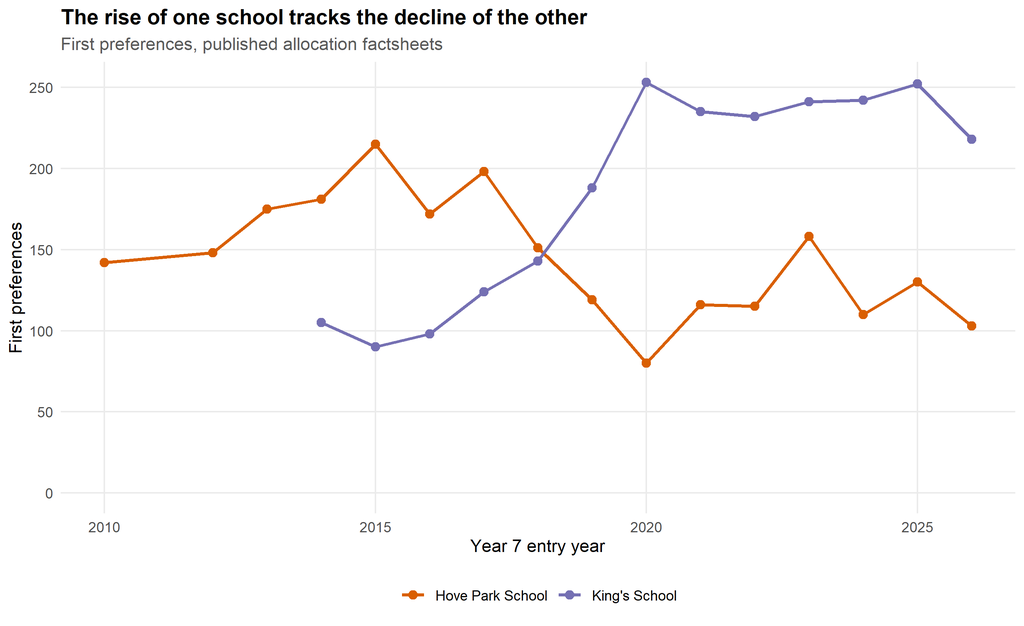

First preferences for King’s School and Hove Park School, from the council’s published allocation factsheets. Nothing here is modelled.

```r
kp <- readRDS(file.path(PUBLIC_OUT, "factsheet_panel.rds"))$factsheets %>%
  filter(grepl("King's|Hove Park", name)) %>%
  mutate(School = if_else(grepl("King", name), "King's School", "Hove Park School"))

kp %>%
  ggplot(aes(year, pref1, colour = School, group = School)) +
  geom_line(linewidth = 1) + geom_point(size = 2.4) +
  scale_colour_manual(values = c("King's School" = "#7570b3",
                                 "Hove Park School" = "#d95f02")) +
  expand_limits(y = 0) +
  labs(title = "The rise of one school tracks the decline of the other",
       subtitle = "First preferences, published allocation factsheets",
       x = "Year 7 entry year", y = "First preferences", colour = NULL) +
  theme(legend.position = "bottom")
```

Between 2014 and 2026, King’s first preferences rose from 105 to 218 while Hove Park’s fell from 181 to 103. Offers moved the same way — King’s from 115 to 180, Hove Park from 260 to 136. **The two series correlate at -0.84 on first preferences and -0.75 on offers.** One school has roughly doubled while the other has roughly halved, over the same twelve years, in the same part of the same city.

That is published data, and it is the whole of what published data can say. The correlation is striking but it is not, by itself, evidence of a mechanism: two schools in the same area with a fixed pool of children will tend to move oppositely whatever the cause, and Hove Park’s own circumstances are an equally available explanation.

**NoteWhat the records show, and why it matters for any further expansion**

Two things that published data cannot reach would settle this, and individual admissions records carry both.

**Whether King’s is, in practice, a Hove catchment school.** Its intake is very likely drawn overwhelmingly from the Hove Park and Blatchington Mill catchment — plausibly taking something like one child in five from it, with no other catchment losing more than a few per cent. It admits on faith criteria and holds no catchment of its own, but there is every reason to expect its draw to be overwhelmingly local.

**Whether it takes the least deprived intake in the city.** Published free school meals figures already point that way, and the gap against Hove Park, in the same part of the city, looks substantial.

Set that against Section 18.1.2, where Hove Park’s own catchment geography is the *least* deprived in the city. The ordering of intakes is the exact inverse of the ordering of the ground the schools stand on. Three institutions draw on the same population; two of them take the less deprived children, and Hove Park takes what is left.

**The question this raises is whether further expansion at King’s is compatible with a viable Hove Park in the medium term.** In a shrinking cohort every additional place at King’s is drawn from a catchment that is itself getting smaller, and — on the evidence above — disproportionately from the less deprived part of it. That reduces Hove Park’s roll and concentrates disadvantage in what remains, at the same time.

It is structurally the same problem as Longhill’s, and harder. Longhill’s levers are catchment, size and site. Hove Park’s competitor has no catchment, admits on criteria the council does not set, and cannot be reached by any instrument used elsewhere in this report.

**The substitution pattern is the decisive test, and it could well revise the hypothesis rather than confirm it.** If families naming King’s first turn mostly to Blatchington Mill and Cardinal Newman as their second choice — the other well-regarded school and the other faith school — rather than to Hove Park, then King’s is not competing with Hove Park at all.

Were that the case, the implication would be uncomfortable: **Hove Park would be dropping out of choice sets** rather than losing a contest for shared families. Constraining King’s would not return them, because they were never moving between those two schools. And Hove Park’s more deprived intake would be a **residual** — what remains after three other institutions have been chosen from across the same catchment — rather than the result of King’s skimming its queue.

The policy implication would follow directly: capping King’s would not fix Hove Park. The question that matters would be why Hove Park is falling out of choice sets across its own catchment, and that is about the school and how it is regarded rather than about admissions arithmetic. No catchment redesign reaches it.

The direction of travel over successive rounds would matter as much as the level — Hove Park falling as a reserve choice for King’s families, while King’s rises as a reserve for Hove Park’s own, would point somewhere quite different from a simple story about creaming.

Two limits on any such test. Preference records for the relevant period would need to reach back before 2020, since King’s grew mainly between 2014 and 2020, and recent rounds show the pattern *now* rather than during the expansion. And second preferences are strategic as well as sincere — families name schools they think they can get.

## 21.1 Hove Park is being chosen against on the wrong measure

The section above leaves an obvious question: if Hove Park is dropping out of choice sets across its own catchment, what are families reacting to? Published data answers this one fully.

```r
av <- inp$attract %>%
  transmute(School = name, `Attainment 8` = round(att8, 1),
            `Progress 8` = round(p8, 2),
            `Intake-adjusted (Lever)` = round(va_lever, 2),
            `Preferences per place` = round(prefs_per_place, 2)) %>%
  arrange(desc(`Attainment 8`))
av %>% tbl(caption = "Three measures of the same schools, against how strongly families choose them")
```

Three measures of the same schools, against how strongly families choose them

| School | Attainment 8 | Progress 8 | Intake-adjusted (Lever) | Preferences per place |
| --- | --- | --- | --- | --- |
| King's School | 56.9 | 0.71 | 2.67 | 1.45 |
| Varndean School | 53.5 | 0.40 | 3.42 | 1.33 |
| Dorothy Stringer School | 53.5 | 0.23 | 3.63 | 0.92 |
| Cardinal Newman Catholic School | 53.1 | 0.37 | -0.58 | 1.22 |
| Blatchington Mill School | 51.0 | 0.10 | 0.42 | 0.93 |
| Patcham High School | 47.8 | -0.27 | -3.79 | 0.88 |
| Portslade Aldridge Community Academy | 45.9 | 0.04 | 1.09 | 0.73 |
| Hove Park School | 45.2 | -0.04 | 0.39 | 0.64 |
| Peacehaven Community School | 40.0 | -0.18 | 0.17 | 0.41 |
| Longhill High School | 37.2 | -0.61 | -2.02 | 0.41 |
| Brighton Aldridge Community Academy | 36.8 | -0.50 | 0.73 | 0.56 |

How strongly families choose a school correlates with **Attainment 8 at 0.94**, with **Progress 8 at 0.91**, and with the **intake-adjusted measure at 0.46**.

The middle figure is the interesting one, and it is a caution about Progress 8 rather than a finding about families. **Progress 8 correlates with Attainment 8 at 0.93** across these eleven schools — it is very nearly a restatement of the raw measure, so it cannot separate “families choose on attainment” from “families choose on progress”. The intake-adjusted measure used in [*How to Pull the Right Lever*](https://adamdennett.github.io/) correlates with Attainment 8 at only 0.52, so it can. And on that measure, families are **not** tracking what schools add.

For Hove Park the consequence is direct. It sits near the bottom on Attainment 8, but on the intake-adjusted measure it is **positive and above Cardinal Newman and Patcham** — two schools chosen substantially more strongly than it is. Brighton Aldridge, which has the lowest Attainment 8 in the city, adds more on this measure than Blatchington Mill, Cardinal Newman or Hove Park.

**WarningThe trap this creates, and why no catchment policy reaches it**

Attainment 8 is very largely a measure of who a school admits rather than what it does with them. That produces a closed loop, and Hove Park is inside it:

1. It receives the residual intake after three other institutions have been chosen from its catchment (Section 21).
2. A more deprived intake produces a lower Attainment 8, almost mechanically.
3. Families choose on Attainment 8, so it is chosen less.
4. Which makes its intake more residual still.

Nothing in that loop requires the school to be getting worse, and the intake-adjusted measure says it is not. **The loop is driven by the measure families use, and it will keep turning regardless of what the school does.**

This is why the levers in the rest of this report do not reach Hove Park. Catchment, admission number and site all change *who is in the queue*. None of them changes what parents are looking at when they choose. Publishing an intake-adjusted measure alongside the raw one — which any authority could do — is the only intervention here that acts on the actual mechanism.

**One thing this cannot settle**: whether families choose on Attainment 8 because they do not know a contribution measure exists, or because they know and prefer the peer group anyway. Those imply completely different remedies — the first is answerable with better published information, the second is not. It is a survey question rather than a data question, and a council could answer it in a single admissions round.

### 21.1.1 Which schools the conflation flatters, and which it buries

The clearest way to see what is at stake is to rank the schools twice — once on the measure families use, once on the measure that isolates what a school contributes — and look at which ones move.

```r
rk <- inp$attract %>%
  filter(!is.na(va_lever), !is.na(att8)) %>%
  mutate(`Rank on Attainment 8` = rank(-att8),
         `Rank on contribution` = rank(-va_lever),
         Movement = `Rank on Attainment 8` - `Rank on contribution`) %>%
  arrange(desc(Movement)) %>%
  transmute(School = name,
            `Attainment 8` = round(att8, 1),
            `Rank on Attainment 8` = round(`Rank on Attainment 8`),
            `Intake-adjusted` = round(va_lever, 2),
            `Rank on contribution` = round(`Rank on contribution`),
            `Places moved` = sprintf("%+d", round(Movement)))
rk %>% tbl(caption = "The same schools ranked on the league-table measure and on what they add. Positive movement means a school does better than its headline score suggests.")
```

The same schools ranked on the league-table measure and on what they add. Positive movement means a school does better than its headline score suggests.

| School | Attainment 8 | Rank on Attainment 8 | Intake-adjusted | Rank on contribution | Places moved |
| --- | --- | --- | --- | --- | --- |
| Brighton Aldridge Community Academy | 36.8 | 11 | 0.73 | 5 | +6 |
| Portslade Aldridge Community Academy | 45.9 | 7 | 1.09 | 4 | +3 |
| Dorothy Stringer School | 53.5 | 3 | 3.63 | 1 | +2 |
| Hove Park School | 45.2 | 8 | 0.39 | 7 | +1 |
| Peacehaven Community School | 40.0 | 9 | 0.17 | 8 | +1 |
| Varndean School | 53.5 | 2 | 3.42 | 2 | +0 |
| Longhill High School | 37.2 | 10 | -2.02 | 10 | +0 |
| Blatchington Mill School | 51.0 | 5 | 0.42 | 6 | -1 |
| King's School | 56.9 | 1 | 2.67 | 3 | -2 |
| Patcham High School | 47.8 | 6 | -3.79 | 11 | -5 |
| Cardinal Newman Catholic School | 53.1 | 4 | -0.58 | 9 | -5 |

**Brighton Aldridge moves furthest.** Last of eleven on Attainment 8 and 5th on contribution — a school with the most disadvantaged intake in the city (48% FSM) doing more for its pupils than most schools with far easier intakes. Portslade Aldridge moves the same way.

**Cardinal Newman and Patcham move furthest the other way**, each falling five places. Both look strong in the league tables and both sit below the city average once intake is accounted for.

**Hove Park sits above Cardinal Newman on contribution** (0.39 against -0.58) while being chosen at roughly half the rate.

**ImportantThis is a communications problem before it is an admissions problem**

Attainment 8 across the city’s schools correlates with intake composition far more strongly than the intake-adjusted measure does — for free school meals eligibility, -0.87 against -0.22.

That contrast is the whole difficulty in one line, and the mechanism behind it is prior attainment rather than disadvantage as such: schools whose intakes arrive with higher Key Stage 2 results post higher Key Stage 4 results, and free school meals eligibility is a visible marker of that intake difference rather than its cause. **A school’s headline score is very largely a description of who walks through its doors**, and families choosing on it are — without meaning to — choosing a peer group and calling it a school. Every mechanism in this report then amplifies that: the schools with the most disadvantaged intakes get the lowest headline scores, are chosen least, and become more disadvantaged still.

**No admissions policy reaches this.** Catchments, admission numbers, open allocation and relocation all change *who is in the queue*. None of them changes what parents believe they are choosing between. An authority that moves children around to equalise intakes, while leaving the measure families use untouched, is treating the symptom every year and never the cause.

What would reach it is publication. **The council could publish an intake-adjusted measure alongside the raw one**, in the admissions booklet where families actually look, with a plain sentence explaining that a school’s headline grade largely reflects who attends it. That is not a costly intervention. It is a page in a document the authority already produces, and it is the only lever in this entire report that acts on the demand side rather than shuffling supply.

It would also be uncomfortable, because it would say publicly that some well-regarded schools add less than their reputation implies, and that Brighton Aldridge — the school the city worries about — is doing better by its pupils than most.

**Two qualifications, because the argument is stronger with them than without.**

The first is that **the popular schools are not simply misjudged.** Dorothy Stringer and Varndean rank 1st and 2nd on contribution as well as near the top on attainment. Families naming them are not making a mistake, and any messaging that implied otherwise would be wrong and would be seen to be wrong. The conflation misleads about the *bottom* of the table far more than the top.

The second is that **it does not rescue every undersubscribed school.** Longhill is 10th on contribution as well as 10th on attainment. Its problem is not that families have misread a good school; on this evidence they have read it accurately. That is worth stating plainly, because the case for Longhill in this report rests on demography and geography, not on a claim that the school is secretly excellent.

### 21.1.2 What the council actually tells parents to look at

This is not a hypothetical failure of communication. The council’s own *Secondary school admissions guide 2026–2027* opens with a section called **“Before you make your application”**, which lists what a family should consider. Under *Look at the school’s prospectus*, it says the prospectus will give an idea of the school’s:

> ethos and character · National Curriculum test results · public exam results

Two of those three are raw attainment. The section goes on to recommend reading Ofsted reports, visiting schools, checking admission numbers and catchment, thinking about travel, and using all four preferences — all sensible, and much of it genuinely useful.

**What the guide never mentions, anywhere, is that a school’s exam results largely describe the children who sit them.** There is no reference to Progress 8, to value added, to contextual measures, or to any figure that separates what a school achieves from who it admits. The performance signals the guide names are exactly the ones that correlate with intake affluence at 0.87.

**ImportantThe authority is not a neutral party in this**

Every mechanism in this report runs on what families believe they are choosing between. The council does not merely observe those beliefs; **it is the single largest source of guidance shaping them.** This document goes to every family in the city applying for a Year 7 place, at the moment they are deciding.

The guidance is not wrong in what it says. It is incomplete in a way that runs consistently in one direction. A parent following it exactly — visiting schools, reading prospectuses, comparing exam results, checking Ofsted — would arrive at the ordering this report shows families actually produce: one that tracks raw attainment closely and what schools contribute barely at all. The guide advises looking widely, including “schools outside your immediate area”, which amplifies rather than moderates the effect.

The result is an authority spending considerable effort on admission arrangements intended to even out school intakes, while its own advice to parents points at the measure that drives them apart. Those two activities work against each other, and only one of them is cheap to change.

**And the format already exists.** Later in the same guide, every school gets a table: number on roll, preferences received at each rank, places offered under each admission criterion, and the admission number. The council is evidently willing and able to publish a per-school table in this document. What that table contains is admissions arithmetic and nothing about what a school does for the children in it.

**Adding a column would do it** - an intake-adjusted measure beside the admission number, with a sentence saying that headline results substantially reflect the attainment of the children who join a school, and that a school with modest raw results may be adding a great deal. No new page, no new format, no new process. A column in a table the council already builds.

It is worth being clear that this is not an accusation of intent. The guide reads like a document assembled to be helpful and complete on process, by people whose job is admissions rather than performance measurement. But the omission is consequential, the authority is the one making it, and it is the cheapest correction available anywhere in this report.

# 22 What if other schools shrink too?

Every scenario so far treats Longhill as the only school whose size is in question. A falling cohort presses on all of them at once, and several have their own reasons to want to be smaller — Cardinal Newman most of all, at 360 by some distance the largest in the city.

This is testable with published data alone: admission numbers are public, and the model already redistributes displaced demand. The scenarios below use the adjudicator’s binding 2026/27 numbers, which matters, because the council’s proposed reductions at Blatchington Mill and Dorothy Stringer were overturned — 60 central places the council meant to remove stay in the system.

```r
po <- readRDS(file.path(PUBLIC_OUT, "pan_scenarios_open.rds"))

po$longhill %>%
  mutate(natural = round(natural)) %>%
  pivot_wider(names_from = entry_year, values_from = natural) %>%
  rename(Scenario = scenario) %>%
  tbl(caption = "Longhill's natural recruitment if other schools reduce their admission numbers")
```

Longhill's natural recruitment if other schools reduce their admission numbers

| Scenario | 2026 | 2030 | 2035 |
| --- | --- | --- | --- |
| S0. As determined | 230 | 175 | 155 |
| A. Cardinal Newman 300 | 230 | 175 | 155 |
| B. Cardinal Newman 270 | 230 | 175 | 155 |
| C. Dorothy Stringer 270 | 249 | 175 | 155 |
| D. BACA 150 | 240 | 175 | 155 |
| E. Newman 270 + Stringer 270 | 249 | 175 | 155 |
| F. Newman 270 + Stringer 270 + BACA 150 | 258 | 175 | 155 |
| G. Dorothy Stringer 300 | 240 | 175 | 155 |
| H. Newman 270 + Stringer 300 + BACA 150 | 249 | 175 | 155 |

**WarningThe open model cannot answer this one, and it is worth saying why**

Reducing Cardinal Newman changes Longhill’s recruitment by **nothing at all** in this model — not a small amount, exactly zero. That is not a finding about Brighton. It is a failure of the open model, and the diagnosis is visible in the capacity table.

**The failure is specific to the faith schools, and the rest of the section should be sound.** The Dorothy Stringer rows come out at +18 children at PAN 270 and +9 at 300, and there is no structural reason to doubt them: Stringer is a community school with no restricted choice set, so displaced demand is modelled the way the rest of the system is.

**The Dorothy Stringer cascade reproduces almost exactly** — 18 against 20 at 270, 9 against 10 at 300. That is a genuine open-data result and it can be relied on.

**The Cardinal Newman rows are the ones to distrust**, and the reason is the one given above: this model lets any family choose a faith school, so cutting Newman’s places displaces children who scatter across the city rather than the subset who would actually have gone there. A model that restricted the faith choice set to families who could realistically gain admission would send those displaced children somewhere much more concentrated, and Longhill — nearest to a large share of Newman’s catchment draw — is where a good many of them would land.

How much is unknowable from published data, but the direction is not, and the stakes are worth stating. If cutting Newman were worth even twenty or thirty children to Longhill, then the combined packages in rows E and F would be worth something in the region of fifty to seventy — against Longhill’s 2026 intake of roughly 130, an increase of a third to a half. **On that reading the size of other schools would be a more powerful instrument for Longhill than anything done to Longhill itself**, and more powerful than relocation and redrawing combined. This model puts row F at +28 and cannot tell you whether that is right.

**Rows C and G can be read from this document. Rows A, B, E and F cannot.**

**Recommendation: the faith-school choice set should be fitted from the records before the cascade is dismissed as an option.** This is the sharpest case in the report of published data producing a wrong answer rather than an imprecise one — a mechanism that may be the most powerful lever available to Longhill is reported here as exactly zero. If the council is weighing admission-number reductions across the city, it needs to know whether reducing Cardinal Newman helps Longhill by thirty children or by none, and the difference between those is a restricted choice set that individual preference records would supply directly.

```r
po$slack %>%
  transmute(School = name, PAN = pan, Intake = round(intake),
            `Spare places` = round(spare)) %>%
  arrange(desc(`Spare places`)) %>%
  head(4) %>%
  tbl(caption = "Where the open model leaves capacity unused, 2026")
```

Where the open model leaves capacity unused, 2026

| School | PAN | Intake | Spare places |
| --- | --- | --- | --- |
| Cardinal Newman Catholic School | 360 | 213 | 147 |
| King's School | 165 | 143 | 22 |
| Blatchington Mill School | 330 | 330 | 0 |
| Brighton Aldridge Community Academy | 180 | 180 | 0 |

The open model has Cardinal Newman recruiting only 213 of its 360 places. Reducing its admission number to 270 therefore binds on nothing, because the school never reaches 270 in the first place.

In reality Cardinal Newman fills every year and is the most oversubscribed school in the city. The open model under-predicts it because the only public signal of a faith school’s popularity is its first-preference count, and that badly understates demand for a school which families know admits on religious criteria — many who would want a place never express the preference. The same weakness that makes Section 7 cautious about attractiveness proxies bites hardest here.

**So this question needs the restricted data.** Individual preference records show Cardinal Newman as by far the most attractive school in Brighton, full at 360, and a reduction to 270 displacing children who cascade towards the two schools with room. This bundle cannot reproduce that, and rather than present a table of zeroes as though it were a result, the honest statement is that the open model is blind to it.

It is the clearest single example in this document of what an origin–destination matrix of preferences would add.

# 23 How much does any of this depend on unknowns?

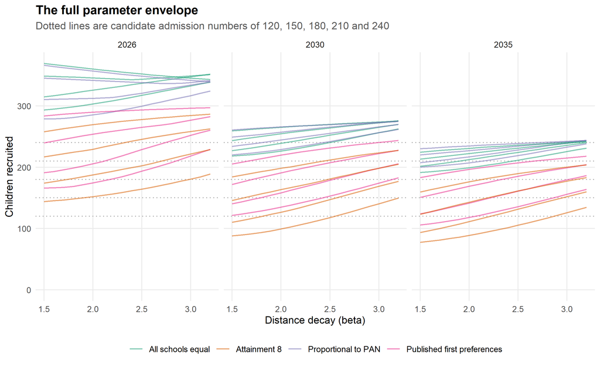

Longhill’s natural intake across every combination swept. Each line is one attractiveness specification at one catchment-effect strength.

```r
env$envelope %>%
  filter(site == "now") %>%
  ggplot(aes(beta, natural_intake, colour = w_label,
             group = interaction(w_label, gamma))) +
  geom_hline(yintercept = env$pans, linetype = "dotted", colour = "grey65") +
  geom_line(alpha = 0.55, linewidth = 0.6) +
  facet_wrap(~ entry_year, nrow = 1) +
  scale_colour_brewer(palette = "Dark2") +
  expand_limits(y = 0) +
  labs(title = "The full parameter envelope",
       subtitle = "Dotted lines are candidate admission numbers of 120, 150, 180, 210 and 240",
       x = "Distance decay (beta)", y = "Children recruited", colour = NULL) +
  theme(legend.position = "bottom")
```

```r
env$importance %>%
  filter(term != "Residuals") %>%
  mutate(term = recode(term,
    "w_spec" = "Which attractiveness specification",
    "factor(entry_year)" = "Which year",
    "factor(gamma)" = "Strength of catchment priority",
    "factor(beta)" = "Distance decay (beta)",
    "site_label" = "Site (Ovingdean or Elm Grove)")) %>%
  transmute(Input = term, `Share of variation (%)` = round(pct, 1)) %>%
  tbl(caption = "What the answer is actually sensitive to")
```

What the answer is actually sensitive to

| Input | Share of variation (%) |
| --- | --- |
| Which attractiveness specification | 43.7 |
| Which year | 26.8 |
| Site (Ovingdean or Elm Grove) | 13.3 |
| Distance decay (beta) | 5.7 |
| Strength of catchment priority | 2.9 |

**NoteWhat restricted data would and would not add**

The single most consequential unknown is **not** how sharply families discount distance. Distance decay accounts for 5.7% of the variation in the answer. **How attractive each school is, net of where it sits, accounts for 43.7%.**

**CautionThe centre of the envelope is probably not the best estimate**

This is the most important thing to know about every range quoted in this document.

At the current site in 2035, the sweep spans **78 to 244 children, with a median of 203.** The calibrated model puts it at about **79** — essentially the floor of the range, not the middle.

The sweep is doing its job: it brackets the plausible answers, which is the point of sweeping rather than guessing. But a reader naturally treats the centre of a range as the best estimate, and there are two reasons to think that would be wrong here — in both cases towards the optimistic side.

The first is visible in the table above. The **attractiveness specification accounts for 43.7% of the variation** — far more than distance decay or catchment priority — and none of the four open specifications capture how strongly families avoid Longhill, because published data does not record avoidance. All four therefore err in the same direction rather than scattering either side of the truth, which is what a median assumes.

The second is the validation: the model over-predicts Longhill against actual offers, and does so consistently. A specification that is known to over-predict does not become unbiased when averaged with three others sharing the same blind spot.

**Read the lower part of every envelope in this document as the operative range, not the median.** Where a figure is quoted with a band around it, the weight of the evidence sits at its pessimistic end.

**Recommendation: replace this sweep with a measurement.** Sweeping is the right response to not knowing, and it is why the conclusions here are stated as ranges. But it is a second-best. The single input that would collapse the widest band in this document — how attractive each school is, net of where it stands — is recoverable from the council’s admissions records by a standard regression, and would turn 43.7% of the uncertainty into a fitted coefficient.

I would carry out that work with the council, share the code and the outputs, and publish nothing disclosive. What the authority would get in return is not a better version of this document: it is a model of its own school system that can be re-run against any proposal before it is consulted on, rather than argued about afterwards.

# 24 What this shows, and what it does not

**What holds without any modelling assumption at all**

- Longhill has the lowest potential accessibility to the city’s children of any secondary school in Brighton (Section 5), at 71 against a city average of 100 — and it has the fewest competing schools nearby, so that is a reach problem rather than a crowding one.
- The Elm Grove site is better placed at every distance decay tested. This is the one conclusion here that requires no view on attractiveness, admissions priority, or family behaviour.

**What holds across the whole envelope**

- Longhill cannot sustain the PAN of 210 now in force into the 2030s: it reaches 90% of that number in only 67% of runs by 2035, and that is on a model already biased in its favour. At the 240 it carried until 2026, 50%.
- A PAN of 120–150 is defensible.
- The 2028 boundary change does not alter this. It adds one school and its own children, and those children live closer to that school than to Longhill.
- The 2024 catchment redraw does not alter it either, in the direction the open model can see (Section 17). Whether it makes Longhill’s position slightly better or slightly worse is beyond what published data can settle.
- Demand tracks published Attainment 8, not value-added.
- Relocating to Elm Grove increases recruitment, in 98% of runs by
  2035. The direction is robust; the size is not, because the model over-predicts Longhill to begin with.

**What this analysis cannot settle**

- *How much* relocation would help. The open model over-predicts Longhill badly, so its estimate of the gain is an upper bound.
- What happens to children academically. This models where they would go, not what happens when they get there — for which see school_attainment_tool, which finds absence a far more powerful lever than any redistribution of intake.
- Anything below catchment level about who goes where.

**Standing limits**

- Travel times are now routed throughout, including the expansion area and the Elm Grove site. The `r5r` network was rebuilt over a merged East and West Sussex extract; no journey time in this document is inferred from straight-line distance.
- The model over-predicts Longhill by 116 children against published offers, so its figures are generous to the school and its relocation gain is an upper bound.
- Ten destinations means anything about *why* a school is attractive rests on ten observations.
- Only the schools inside the authority are modelled as destinations. Routed times to Seahaven, Priory Lewes and Seaford Head now exist but are not yet used, so eastern children have nowhere to go in the model except Brighton or Peacehaven — which overstates the inflow to the city.

# 25 What the council’s own data would settle

This document is built entirely from published sources, and that constraint has been productive: it forces every claim to be checkable by anyone. But it has been binding at specific, identifiable points, and it is worth naming them — partly so readers know where the analysis is weakest, and partly because the data that would fix them already exists.

The council holds individual preference and offer records: for each applicant, the schools named in order, the criterion under which a place was allocated, and the home postcode. Nothing below needs anything the admissions process does not already generate.

**Where the open model is demonstrably wrong, and would stop being.** The validation in Section 23 shows this model over-predicting Longhill by a wide margin once routed journey times are used. The reason is structural: the model can see how reachable a school is, but nothing in published data records how strongly families *avoid* one. Preference records supply exactly that, as a school-level term fitted rather than assumed. Until then every relocation figure here is an upper bound, and the report says so repeatedly because it is the single largest source of error in it.

**Whether catchment priority is worth anything.** This document has to assume a value for how much being in catchment shifts a family’s choice, and sweeps it across a wide band because the assumption cannot be tested openly. Records settle it directly, by school: compare offer rates for in-catchment and out-of-catchment applicants who named the same school. The expected answer at Longhill is **close to nothing**, since an undersubscribed school turns almost nobody away whether they live in catchment or out. If that is borne out, redrawing Longhill’s catchment cannot work through priority at all — only through what families are willing to name. That is a conclusion with direct policy consequences and it is invisible in published data.

**Choice or chance.** The consultation argument that dual catchments confer “choice” can only be tested against individual preferences. The relevant number is the share of in-catchment applicants who named a school first and were refused it. The expectation is that it runs high at the oversubscribed school in a pair and near zero at the others — in which case the “choice” is real at some schools and a lottery at others. Published aggregates cannot distinguish those two situations at all.

**How much deprivation the catchment averages conceal.** Section 18.1.2 shows the pairing masking a substantial social boundary in Hove, but understating it: about 18 percentage points here, and address-level data would very likely show it wider. Postcode-level home addresses would remove the approximation entirely, and with it the caveat that currently sits on the most policy-relevant finding in this document.

**Who leaves, and why.** Roughly a fifth of the city’s children do not enter its state secondary schools. Published data cannot say whether they go independent, to a faith school, or out of the authority, nor where they live. Records can, and the east-of-the-city pattern that emerges is central to any judgement about Longhill’s future.

Five sections of this report exist only to mark where published data runs out: Section 6, Section 9, Section 11, Section 12 and Section 19. Each says what cannot be established here and what the records would establish. They are the shape of the offer.

None of this requires new collection, a survey, or a change of practice. It requires access to records the admissions process produces as a by-product, under the arrangements that already govern research use of pupil data.

## 25.1 And one thing that needs no arrangements at all

There is a smaller ask that could be met immediately, and it is worth separating from the rest because it involves no personal data and no agreement of any kind.

When the adjudicator determined the 2026/27 objections, the council produced an evidence bundle: catchment boundaries, pupil forecasts, deprivation indices, and **preference and allocation counts by catchment area** — which school each catchment’s children named, in what order, and where they were offered places. As set out in Section 2.1, that material reached me as an objector to the case but was never published.

**Publishing that bundle would cost the council nothing and would let every party to this debate argue from the same evidence.** At present the authority, the objectors and the adjudicator have seen it; residents, governors and anyone reading this document have not. For a decision that will shape the city’s schools for fifteen years, that asymmetry is hard to justify — and unlike the pupil-record request above, removing it requires no one’s permission but the council’s own.

## 25.2 Why this is worth doing now rather than later

The case is not that the analysis would be interesting. It is that the city is about to make a series of decisions that will bind for fifteen to twenty years, and is making them one at a time.

Consider what is in front of the council across the next few rounds: Longhill’s admission number and possibly its site; Dorothy Stringer’s admission number, already once refused by the adjudicator; the free school meals criterion, whose reach is about to be cut by nearly half by a change in national eligibility rules; the catchment map, redrawn in 2024 and not yet settled; and the arrival of four wards and a further secondary school in 2028. Each of these is currently a separate decision with a separate evidence base and a separate consultation.

**They are not separate.** Every result in this document says so. Reducing one school’s admission number pushes demand onto its neighbours and the effect concentrates, unevenly, on the school least able to absorb it. Redrawing a catchment changes who is in it, and therefore the social composition of two schools, not one. Relocating a school severs it from part of its hinterland while gaining another part. A model of the whole system is the only way to see any of that before it happens rather than afterwards.

The demographic reality makes this urgent rather than optional. The cohort is falling, the fall is not evenly distributed across the city, and surplus capacity has to land somewhere. A city that decides where it lands, deliberately and once, will get a better answer than one that discovers where it landed after five years of separate decisions each of which seemed reasonable in isolation.

That is what this work is for. It is not an argument for any particular outcome for Longhill, or for any school — the results here point in different directions depending on what the city decides it values, and the report says so wherever that happens. It is an argument for having the conversation with the whole picture in view, and for doing so while there is still time for the answer to matter.

The offer stands: the model, the code, and the analysis are open, and the parts that need records will be done properly and shared if the records are made available.